# Tarea 1 — Series de tiempo

**Mostrar/ocultar código**

```r
#Ajustar doble media móvil
modelo_pet <- ajustar_dmm(
  y = y_estimacion_pet,
  k = resultado_opt_pet$optimo$k
)

pronosticos_pet <- modelo_pet$pronosticar(h)
```

**Mostrar/ocultar código**

```r
cat(
  "Horizonte de validación (h):", h, "\n",
  "Pronóstico:", round(pronosticos_pet[1:4], 4), "\n"
)
```

```
Horizonte de validación (h): 12
 Pronóstico: 0.1173 0.1169 0.1165 0.1162
```

Los pronósticos de la doble media móvil se mantienen alrededor de 0.117 y disminuyen ligeramente con el horizonte. Esto muestra que el modelo espera que el precio se mantenga relativamente estable, con una pequeña reducción en los siguientes periodos.

**Medidas de error**

**Mostrar/ocultar código**

```r
# Medidas de error en el período de validación
medidas_pet <- medidas(
  y = y_validacion_pet,
  yhat = pronosticos_pet
)
```

**Mostrar/ocultar código**

```r
# Pronósticos del método ingenuo
pronosticos_ingenuo_pet <- rep(
  y_estimacion_pet[length(y_estimacion_pet)],
  h
)

# Medidas de error del ingenuo
medidas_ingenuo_pet <- medidas(
  y = y_validacion_pet,
  yhat = pronosticos_ingenuo_pet
)
```

**Mostrar/ocultar código**

```r
# Escala del MASE usando el ingenuo en estimación
escala_mase_pet <- mean(
  abs(
    y_estimacion_pet[2:length(y_estimacion_pet)] -
    y_estimacion_pet[1:(length(y_estimacion_pet) - 1)]
  )
)

# MASE correcto de cada método
mase_media_pet <- medidas_pet$MAD / escala_mase_pet
mase_ingenuo_pet <- medidas_ingenuo_pet$MAD / escala_mase_pet

# Tabla de comparación
comparacion_pet <- data.frame(
  Método = c("Doble Media móvil", "Ingenuo"),
  MSE = c(medidas_pet$MSE, medidas_ingenuo_pet$MSE),
  MAD = c(medidas_pet$MAD, medidas_ingenuo_pet$MAD),
  MAPE = c(medidas_pet$MAPE, medidas_ingenuo_pet$MAPE),
  MASE = c(mase_media_pet, mase_ingenuo_pet)
)

comparacion_pet
```

| Método | MSE | MAD | MAPE | MASE |
| --- | --- | --- | --- | --- |
| Doble Media móvil | 2.408507e-06 | 0.001186127 | 1.024737 | 0.6433028 |
| Ingenuo | 5.922816e-06 | 0.002248040 | 1.953651 | 1.2192369 |

En la validación, la doble media móvil obtiene menores errores que el método ingenuo en todas las medidas: MSE, MAD, MAPE y MASE. En particular, su MAPE es 1.02 %, frente a 1.95 % del método ingenuo, lo que indica que sus pronósticos se acercan más a los valores reales en este periodo de validación.

**Validación de los errores**

**Mostrar/ocultar código**

```r
# Posiciones donde existe pronóstico
posiciones_pet <- which(!is.na(modelo_pet$yhat))

# Errores de un paso
errores_pet <-
  y_estimacion_pet[posiciones_pet] -
  modelo_pet$yhat[posiciones_pet]
```

**Mostrar/ocultar código**

```r
resultado_errores_pet <- validar_errores(
  e = errores_pet,
  m = NULL,
  p = 1
)
```

**Gráfico**

**Mostrar/ocultar código**

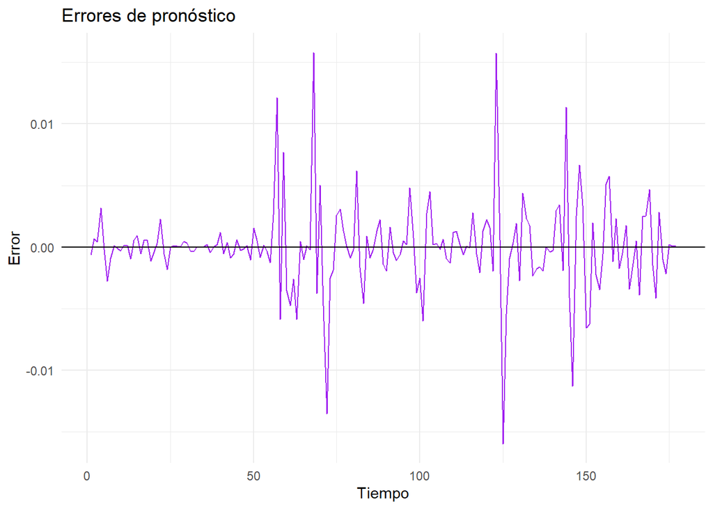

```r
resultado_errores_pet$grafico_errores
```

**Correlograma**

**Mostrar/ocultar código**

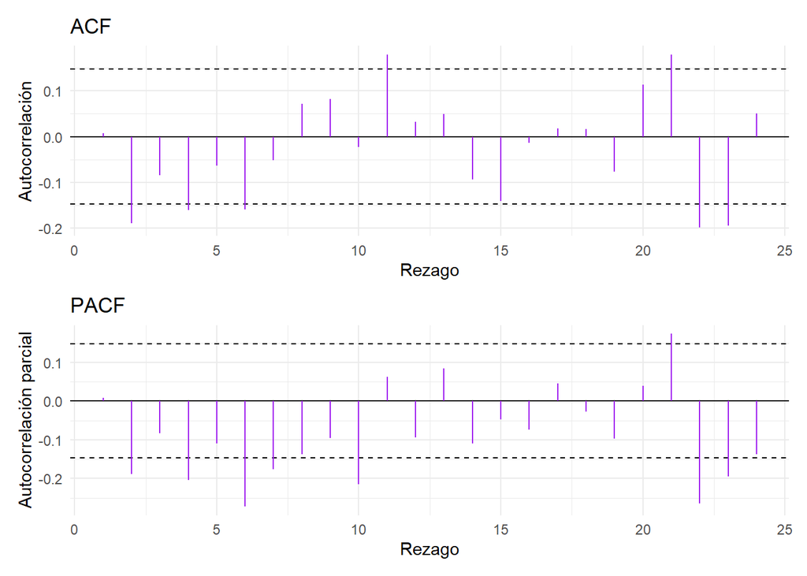

```r
resultado_errores_pet$correlograma$grafico
```

En el ACF, algunos rezagos se salen de la banda sin un patrón fijo que se repita. En el PACF pasa algo parecido, con varios rezagos fuera de la banda. Esto confirma que aún queda algo de dependencia que el modelo no capturó del todo.

**Prueba t**

Prueba de Hipótesis

$$H_0: \mu_e = 0$$
$$H_1: \mu_e \neq 0$$

Estadístico de Prueba:

$$t = \frac{\bar{e}}{s_e / \sqrt{n}}$$

**Mostrar/ocultar código**

```r
cat(
  "Estadístico de prueba:", round(resultado_errores_pet$t, 4), "\n",
  "Grados de libertad:", resultado_errores_pet$grados_libertad_t, "\n",
  "Valor crítico:", round(
    qt(0.975, resultado_errores_pet$grados_libertad_t), 4
  ), "\n",
  "Valor p:", round(resultado_errores_pet$valor_p_t, 4), "\n"
)
```

```
Estadístico de prueba: 0.0023
 Grados de libertad: 176
 Valor crítico: 1.9735
 Valor p: 0.9981
```

Como $t=0.0023$ es menor que el valor crítico $1.9735$ y el valor p es $0.9981$, no se rechaza $H_0$. No hay evidencia de que la media de los errores sea diferente de cero, por lo que no se observa un sesgo sistemático del modelo hacia sobreestimar o subestimar.

**Ljung Box**

Prueba de Hipótesis

$$H_0:\rho_1=\rho_2=\cdots=\rho_{24}=0$$
$$H_1:\text{al menos una }\rho_h\neq0$$

Estadístico de Prueba

$$Q = T(T + 2) \sum_{h=1}^{24} \frac{{r}_h^2}{T - h}$$

Distribución

$$Q \sim \chi^2_{23}$$

Región de Rechazo

$$Q > \chi^2_{0.95, 23}$$

**Mostrar/ocultar código**

```r
cat(
  "Estadístico de prueba:", round(
    resultado_errores_pet$ljung_box$estadistico, 4
  ), "\n",
  "Grados de libertad:", resultado_errores_pet$ljung_box$grados_libertad, "\n",
  "Valor crítico:", round(
    resultado_errores_pet$ljung_box$valor_critico, 4
  ), "\n",
  "Valor p:", round(
    resultado_errores_pet$ljung_box$valor_p, 4
  ), "\n"
)
```

```
Estadístico de prueba: 59.7425
 Grados de libertad: 23
 Valor crítico: 35.1725
 Valor p: 0
```

**Jarque Bera**

Prueba de Hipótesis

$$H_0:\text{los errores tienen distribución normal}$$
$$H_1:\text{los errores no tienen distribución normal}$$

Distribución Bajo $H_0$:

$$JB \sim \chi^2_{2}$$

Estadístico de Prueba

$$JB = \frac{n}{6} \left( A^2 + \frac{(K - 3)^2}{4} \right)$$

Región de rechazo
$$JB>\chi^2_{0.95,2}$$

**Mostrar/ocultar código**

```r
cat(
  "Estadístico de prueba:", round(
    resultado_errores_pet$jarque_bera$estadistico, 4
  ), "\n",
  "Grados de libertad:", resultado_errores_pet$jarque_bera$grados_libertad, "\n",
  "Valor crítico:", round(
    resultado_errores_pet$jarque_bera$valor_critico, 4
  ), "\n",
  "Valor p:", format.pval(
    resultado_errores_pet$jarque_bera$valor_p,
    digits = 4
  ), "\n"
)
```

```
Estadístico de prueba: 342.9346
 Grados de libertad: 2
 Valor crítico: 5.9915
 Valor p: < 2.2e-16
```

Como $JB=342.9346$ es mucho mayor que el valor crítico $5.9915$ y el valor p es menor que $2.2e^{-16}$, se rechaza $H_0$. Existe evidencia de que los errores no siguen una distribución normal.

**Durbin Watson**

Prueba de Hipótesis:

$$H_0:\rho=0$$
$$H_1:\rho\neq0$$

Estadístico de Prueba:

$$DW=\frac{\sum_{t=2}^{n}(e_t-e_{t-1})^2} {\sum_{t=1}^{n}e_t^2}$$

**Mostrar/ocultar código**

```r
cat(
  "Estadístico de prueba:", round(
    resultado_errores_pet$durbin_watson$estadistico, 4
  ), "\n",
  "Grados de libertad: no aplica\n",
  "Valor crítico: no calculado\n",
  "Valor p: no calculado\n"
)
```

```
Estadístico de prueba: 1.9844
 Grados de libertad: no aplica
 Valor crítico: no calculado
 Valor p: no calculado
```

El estadístico Durbin-Watson fue $DW=1.9844$, un valor muy cercano a 2. Esto sugiere que existe poca autocorrelación entre errores consecutivos, aunque esta medida por sí sola no incluye una prueba formal de significancia en este análisis.

**Gráfico Final**

**Mostrar/ocultar código**

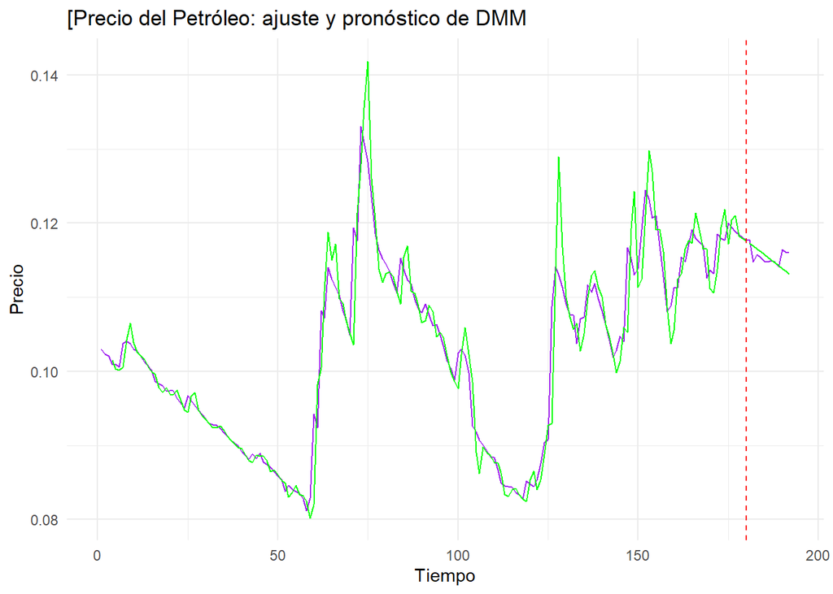

```r
ggplot2::ggplot(
  data.frame(
    tiempo = 1:T_pet,
    real = datos_pet$y,
    ajuste = c(modelo_pet$yhat, rep(NA, h_pet)),
    pronostico = c(rep(NA, T_pet - h_pet), pronosticos_pet)
  ),
  ggplot2::aes(x = tiempo)
) +

  ggplot2::geom_line(
    ggplot2::aes(y = real),
    color = "purple"
  ) +

  ggplot2::geom_line(
    ggplot2::aes(y = ajuste),
    color = "green"
  ) +

  ggplot2::geom_line(
    ggplot2::aes(y = pronostico),
    color = "green"
  ) +

  ggplot2::geom_vline(
    xintercept = T_pet - h_pet,
    color = "red",
    linetype = "dashed"
  ) +

  ggplot2::labs(
    title = "[Precio del Petróleo: ajuste y pronóstico de DMM",
    x = "Tiempo",
    y = "Precio"
  ) +

  ggplot2::theme_minimal()
```

El gráfico muestra la relación entre los precios reales del petróleo y la estimación del modelo a lo largo del tiempo. En la sección histórica, ubicada a la izquierda de la línea roja punteada, se observa un seguimiento muy cercano entre la línea verde y la línea morada, lo que indica que el modelo logra acompañar las alzas, caídas y giros del mercado. Por otro lado, en el tramo de pronóstico a la derecha de la línea roja, la trayectoria del modelo toma una dirección descendente, mientras que el precio real presenta un leve incremento hacia el final del periodo. En resumen, el modelo muestra una buena capacidad para adaptarse a los datos pasados, aunque para el periodo futuro proyecta valores un poco menores a los que se registraron en la realidad.

**Conclusión**

La serie de Precio del Petróleo se modeló con doble media móvil, con k=2, elegido por optimizar() sobre el tramo de estimación (180 observaciones), validando con las últimas 12. En validación, el método obtuvo un MSE de 2.41e-06 y un MASE de 0.6433, frente a 5.92e-06 y 1.2192 del ingenuo, cortando el error casi a la mitad. La prueba t de media cero no mostró sesgo (t=0.0023, valor p=0.9981), pero Ljung-Box sí encontró autocorrelación en los errores (Q=59.7425, valor p<0.0001), con varios picos grandes visibles en el gráfico de errores, y Jarque-Bera rechazó normalidad (valor p<2.2e-16), probablemente por esos mismos picos atípicos.

### 3.5 Población Australiana

**Descripción de la serie**

**Mostrar/ocultar código**

```r
#Crear dataframe con los resultados
propiedades_austres <- data.frame(
  Métrica    = c("Longitud de la serie (n)",
                 "Año de inicio",
                 "Año de fin",
                 "Frecuencia observada"),
  Valor      = c(length(datos_austres$y),
                 start(austres)[1],
                 end(austres)[1],
                 frequency(austres)),
  Descripción = c("Número total de observaciones trimestrales",
                  "Primer año registrado en la serie",
                  "Último año registrado en la serie",
                  "Frecuencia trimestral de medición (4 datos/año)"),
  stringsAsFactors = FALSE
)

#Visualización de la tabla
kable(propiedades_austres,
      format    = "html",
      col.names = c("Métrica", "Valor", "Descripción"),
      align     = c("l", "c", "l"),
      caption   = "Propiedades temporales — Serie de Población Australiana") |>
  kable_styling(bootstrap_options = "basic",
                full_width         = FALSE,
                position          = "center") |>
  row_spec(0, bold = TRUE) |>
  row_spec(1:nrow(propiedades_austres), extra_css = "border-bottom: none;") |>
  column_spec(1:3, border_left = FALSE, border_right = FALSE) |>
  add_header_above(c(" " = 3), line = TRUE, bold = TRUE) |>
  row_spec(nrow(propiedades_austres), extra_css = "border-bottom: 1px solid black;")
```

Propiedades temporales — Serie de Población Australiana

| Métrica | Valor | Descripción |
| --- | --- | --- |
| Longitud de la serie (n) | 89 | Número total de observaciones trimestrales |
| Año de inicio | 1971 | Primer año registrado en la serie |
| Año de fin | 1993 | Último año registrado en la serie |
| Frecuencia observada | 4 | Frecuencia trimestral de medición (4 datos/año) |

La Serie tiene 89 observaciones con frecuencia trimestral, abarca desde 1971 hasta 1993.

**Exploración de la serie**

**Gráficos**

**Mostrar/ocultar código**

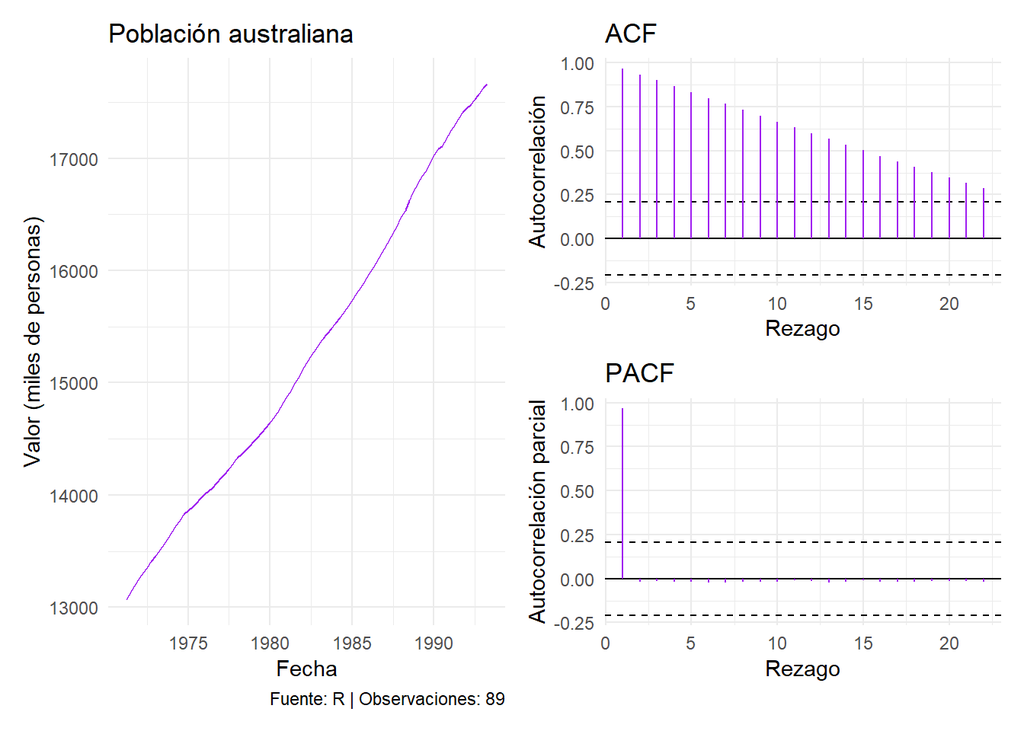

```r
datos_austres <- leer_serie(
  austres,
  fuente = "R",
  unidad = "miles de personas"
)

grafico_austres <- graficar_serie(
  datos_austres,
  "Población australiana"
)

cor_austres <- correlograma(
  datos_austres$y
)

panel_austres <- panel_diagnostico(
  grafico_austres,
  cor_austres
)

print(panel_austres)
```

La serie presenta tendencia creciente, no es estacionaria y no sugiere un comportamiento estacional.

**Contraste individual de los \(r_h\)**

Prueba de Hipótesis

$$H_0:\rho_h=0$$
$$H_1:\rho_h\neq0$$

Estadístico de Prueba:

$$Z_h=\frac{r_h}{1/\sqrt{89}}$$

Distribución bajo $H_0$:

$$Z_h\sim N(0,1)$$

Región de rechazo al 5 %:

$$|Z_h|>1.96$$

**Mostrar/ocultar código**

```r
#Contraste Individual
r_austres <- cor_austres$acf

T_austres <- length(datos_austres$y)

z_austres <- r_austres * sqrt(T_austres)

valor_p_austres <- 2 * pnorm(-abs(z_austres))

valor_critico_austres <- qnorm(0.975)

tabla_acf_austres <- data.frame(
  rezago = 1:length(r_austres),
  r_h = r_austres,
  estadistico = z_austres,
  valor_p = valor_p_austres,
  significativo = abs(z_austres) > valor_critico_austres
)

# Ajustar el data frame para mejorar la presentación numérica
tabla_acf_austres_formato <- tabla_acf_austres
tabla_acf_austres_formato$r_h         <- round(tabla_acf_austres_formato$r_h, 4)
tabla_acf_austres_formato$estadistico <- round(tabla_acf_austres_formato$estadistico, 4)
tabla_acf_austres_formato$valor_p     <- format.pval(tabla_acf_austres_formato$valor_p, digits = 4, eps = 0.0001)
tabla_acf_austres_formato$significativo <- ifelse(tabla_acf_austres_formato$significativo, "Sí", "No")

#Visualización estilo APA
kable(tabla_acf_austres_formato,
      format    = "html",
      col.names = c("Rezago ($h$)", "Autocorrelación ($r_h$)", "Estadístico ($z$)", "Valor $p$", "Significativo"),
      align     = c("c", "c", "c", "c", "c"),
      caption   = "Contraste individual de autocorrelación — Serie de Población Australiana") |>
  kable_styling(bootstrap_options = "basic",
                full_width         = FALSE,
                position          = "center") |>
  row_spec(0, bold = TRUE) |>
  row_spec(1:nrow(tabla_acf_austres_formato), extra_css = "border-bottom: none;") |>
  column_spec(1:5, border_left = FALSE, border_right = FALSE) |>
  add_header_above(c(" " = 5), line = TRUE, bold = TRUE) |>
  row_spec(nrow(tabla_acf_austres_formato), extra_css = "border-bottom: 1px solid black;")
```

Contraste individual de autocorrelación — Serie de Población Australiana

| Rezago ($h$) | Autocorrelación ($r_h$) | Estadístico ($z$) | Valor $p$ | Significativo |
| --- | --- | --- | --- | --- |
| 1 | 0.9666 | 9.1188 | < 1e-04 | Sí |
| 2 | 0.9330 | 8.8023 | < 1e-04 | Sí |
| 3 | 0.8998 | 8.4886 | < 1e-04 | Sí |
| 4 | 0.8665 | 8.1742 | < 1e-04 | Sí |
| 5 | 0.8330 | 7.8584 | < 1e-04 | Sí |
| 6 | 0.7993 | 7.5405 | < 1e-04 | Sí |
| 7 | 0.7654 | 7.2209 | < 1e-04 | Sí |
| 8 | 0.7317 | 6.9030 | < 1e-04 | Sí |
| 9 | 0.6982 | 6.5866 | < 1e-04 | Sí |
| 10 | 0.6647 | 6.2709 | < 1e-04 | Sí |
| 11 | 0.6318 | 5.9604 | < 1e-04 | Sí |
| 12 | 0.5993 | 5.6534 | < 1e-04 | Sí |
| 13 | 0.5665 | 5.3439 | < 1e-04 | Sí |
| 14 | 0.5339 | 5.0371 | < 1e-04 | Sí |
| 15 | 0.5020 | 4.7360 | < 1e-04 | Sí |
| 16 | 0.4702 | 4.4363 | < 1e-04 | Sí |
| 17 | 0.4385 | 4.1372 | < 1e-04 | Sí |
| 18 | 0.4069 | 3.8390 | 0.0001236 | Sí |
| 19 | 0.3759 | 3.5462 | 0.0003908 | Sí |
| 20 | 0.3453 | 3.2578 | 0.0011229 | Sí |
| 21 | 0.3152 | 2.9738 | 0.0029416 | Sí |
| 22 | 0.2853 | 2.6917 | 0.0071079 | Sí |

Los 22 rezagos evaluados presentan autocorrelaciones estadísticamente significativas. La autocorrelación es muy alta y positiva en los primeros rezagos, comenzando en 0.9666 en el rezago 1, y disminuye de manera gradual hasta 0.2853 en el rezago 22. Todos los valores de autocorrelación mantienen el signo positivo y no se observan cambios bruscos de comportamiento.

Esta disminución lenta y continua de la autocorrelación indica una fuerte dependencia temporal entre las observaciones: los valores cercanos en el tiempo tienden a presentar comportamientos similares. La forma del correlograma es compatible con una serie que presenta una tendencia marcada. A partir de estos rezagos no se observa una oscilación repetitiva clara que permita identificar directamente un patrón estacional o cíclico.

**Ljung Box**

Prueba Hipótesis

$$H_0:\rho_1=\rho_2=\cdots=\rho_{22}=0$$
$$H_1:\text{al menos una }\rho_h\neq0$$

Estadístico de Prueba

$$Q = T(T + 2) \sum_{h=1}^{22} \frac{{r}_h^2}{T - h}$$

Distribución

$$Q \sim \chi^2_{22}$$

Región de Rechazo

$$Q > \chi^2_{0.95, 22}$$

**Mostrar/ocultar código**

```r
#Ljung Box
resultado_lb_austres <- ljung_box(
  r = cor_austres$acf,
  T = length(datos_austres$y),
  m = length(cor_austres$acf),
  p = 0
)

cat(
  "Población australiana → Q =", round(resultado_lb_austres$estadistico, 4),
  "| gl =", resultado_lb_austres$grados_libertad,
  "| valor crítico =", round(resultado_lb_austres$valor_critico, 4),
  "| p-valor =", round(resultado_lb_austres$valor_p, 4), "\n"
)
```

```
Población australiana → Q = 938.9522 | gl = 22 | valor crítico = 33.9244 | p-valor = 0
```

Como $Q=938.95$ supera ampliamente el valor crítico de $33.9244$, se rechaza $H_0$, con un valor p menor que 0.0001. Por lo tanto, hay evidencia estadísticamente significativa de que las autocorrelaciones, consideradas conjuntamente, no son todas iguales a cero. La serie no se comporta como ruido blanco y presenta una dependencia temporal marcada, consistente con las autocorrelaciones positivas y significativas observadas en los primeros 22 rezagos.

**Estimación y Validación**

**Partición de la serie**

**Mostrar/ocultar código**

```r
#Partición de la serie
h_austres <- min(
  12,
  floor(0.2 * T_austres)
)

y_estimacion_austres <- datos_austres$y[1:(T_austres - h_austres)]

y_validacion_austres <- datos_austres$y[(T_austres - h_austres + 1):T_austres]

cat(
  "Población australiana → Estimación =", length(y_estimacion_austres),
  "| Validación =", length(y_validacion_austres), "\n"
)
```

```
Población australiana → Estimación = 77 | Validación = 12
```

De las 89 observaciones totales, 77 se dejaron para ajustar el modelo y las últimas 12 para probarlo.

**Tendencia lineal**

**Mostrar/ocultar código**

```r
#Ajustar Tendencia Lineal
modelo_austres <- ajustar_tendencia(
  y_estimacion_austres,
  "lineal"
)

#Pronósticos
pronosticos_austres <- modelo_austres$pronosticar(h_austres)

cat(
  "Horizonte de validación (h):", h_austres, "\n",
  "Pronósticos:", round(pronosticos_austres, 4), "\n"
)
```

```
Horizonte de validación (h): 12
 Pronósticos: 16918.47 16969.18 17019.89 17070.59 17121.3 17172.01 17222.72 17273.42 17324.13 17374.84 17425.54 17476.25
```

Los 12 valores proyectados van subiendo de forma pareja, de 16918.47 a 17476.25, con incrementos casi idénticos entre un trimestre y el siguiente (alrededor de 50 unidades cada vez). Tiene sentido: al ser una recta, el modelo agrega siempre lo mismo por periodo, sin acelerar ni frenar.

**Medidas de error**

**Mostrar/ocultar código**

```r
#Medidas de error
posiciones_austres <- which(
  !is.na(modelo_austres$yhat)
)

medidas_estimacion_austres <- medidas(
  y_estimacion_austres[posiciones_austres],
  modelo_austres$yhat[posiciones_austres]
)

medidas_validacion_austres <- medidas(
  y_validacion_austres,
  pronosticos_austres
)
```

**Mostrar/ocultar código**

```r
# Pronósticos del método ingenuo
pronosticos_ingenuo_austres <- rep(
  y_estimacion_austres[length(y_estimacion_austres)],
  h_austres
)
```

**Mostrar/ocultar código**

```r
# Medidas de error del ingenuo
medidas_ingenuo_austres <- medidas(
  y = y_validacion_austres,
  yhat = pronosticos_ingenuo_austres
)
```

**Mostrar/ocultar código**

```r
# Escala del MASE usando el ingenuo en estimación
escala_mase_austres <- mean(
  abs(
    y_estimacion_austres[2:length(y_estimacion_austres)] -
    y_estimacion_austres[1:(length(y_estimacion_austres) - 1)]
  )
)
```

**Mostrar/ocultar código**

```r
# MASE correcto de cada método (estimación y validación)
mase_estim_austres <- medidas_estimacion_austres$MAD / escala_mase_austres
mase_valid_austres <- medidas_validacion_austres$MAD / escala_mase_austres
mase_ingenuo_austres <- medidas_ingenuo_austres$MAD / escala_mase_austres
```

**Mostrar/ocultar código**

```r
# Tabla única de comparación
tabla_medidas_austres <- data.frame(
  Tramo = c("Estimación", "Validación", "Validación"),
  Método = c("Tendencia lineal", "Tendencia lineal", "Ingenuo"),
  MSE = c(
    medidas_estimacion_austres$MSE,
    medidas_validacion_austres$MSE,
    medidas_ingenuo_austres$MSE
  ),
  MAD = c(
    medidas_estimacion_austres$MAD,
    medidas_validacion_austres$MAD,
    medidas_ingenuo_austres$MAD
  ),
  MAPE = c(
    medidas_estimacion_austres$MAPE,
    medidas_validacion_austres$MAPE,
    medidas_ingenuo_austres$MAPE
  ),
  MASE = c(
    mase_estim_austres,
    mase_valid_austres,
    mase_ingenuo_austres
  )
)

tabla_medidas_austres
```

| Tramo | Método | MSE | MAD | MAPE | MASE |
| --- | --- | --- | --- | --- | --- |
| Estimación | Tendencia lineal | 8865.367 | 82.09324 | 0.5479923 | 1.552745 |
| Validación | Tendencia lineal | 44430.965 | 210.08043 | 1.2071256 | 3.973548 |
| Validación | Ingenuo | 133004.791 | 322.04167 | 1.8405114 | 6.091229 |

En estimación, el ajuste tuvo un MSE de 8865.37, un MAD de 82.09 y un MAPE de apenas 0.55%, señal de un error muy pequeño frente a una serie que ronda los 13000-17000. En validación, el MSE subió a 44430.97, el MAD a 210.08 y el MAPE a 1.21%. Aunque el error creció, sigue siendo bajo en términos relativos.

Frente al ingenuo, la tendencia lineal gana en validación: MSE de 44430.97 contra 133004.79, y MAPE de 1.21% contra 1.84%. La diferencia tiene sentido, porque la población crece de forma constante y una recta describe eso mucho mejor que repetir el último dato.

**Validación de los errores**

Para la validación de errores se utilizaron 77 errores

**Mostrar/ocultar código**

```r
# Errores de pronóstico dentro de la estimación

posiciones_austres <- which(!is.na(modelo_austres$yhat))

errores_austres <- y_estimacion_austres[posiciones_austres] - modelo_austres$yhat[posiciones_austres]

#Validación de los errores
resultado_errores_austres <- validar_errores(
  e = errores_austres,
  m = NULL,
  p = 2    # tendencia lineal: 2 parámetros (intercepto y pendiente)
)
```

**Gráfico**

**Mostrar/ocultar código**

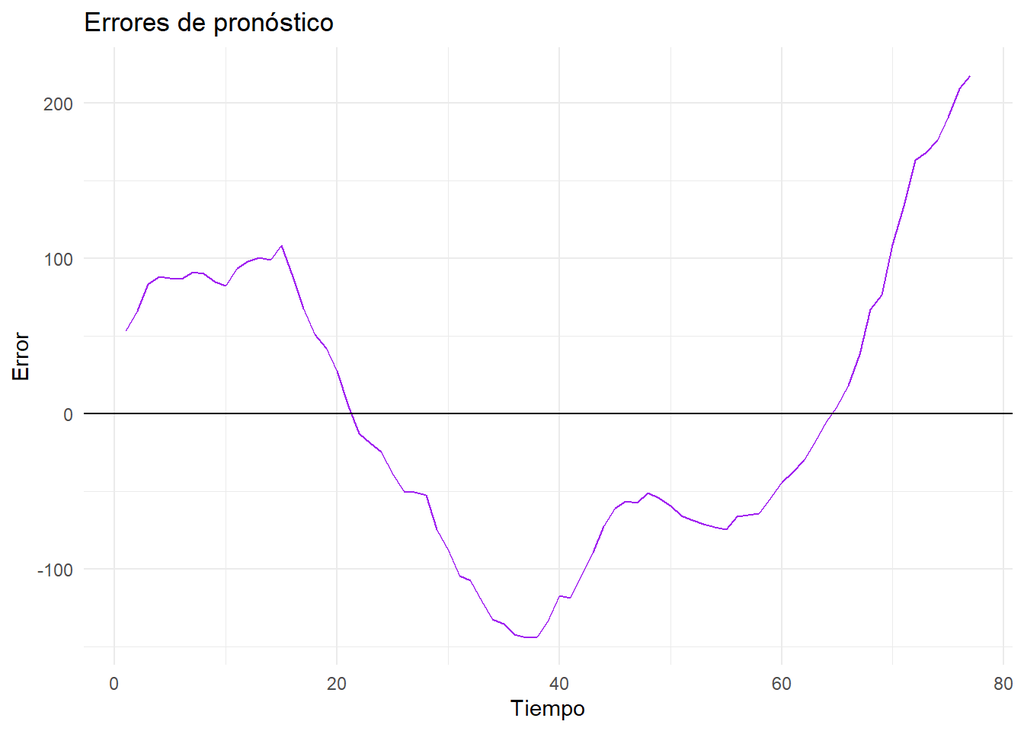

```r
resultado_errores_austres$grafico_errores
```

El patrón de los errores no parece aleatorio, sino que presenta una estructura suave y persistente. Los errores comienzan siendo positivos, con valores superiores a 50, y aumentan hasta alcanzar un máximo cercano a 110 alrededor del período 15. Posteriormente, disminuyen y se vuelven negativos, alcanzando un mínimo cercano a -140 entre los períodos 35 y 40. Finalmente, vuelven a aumentar y superan los 200 hacia el final de la serie.

Este comportamiento en forma de onda indica que los errores presentan una estructura temporal que el modelo de tendencia lineal no logra capturar completamente. La recta tiende a sobreestimar en algunos tramos y a subestimar en otros, lo que puede estar relacionado con cambios en la pendiente o con cierta curvatura de la serie que no es representada por una tendencia lineal.

**Correlograma**

**Mostrar/ocultar código**

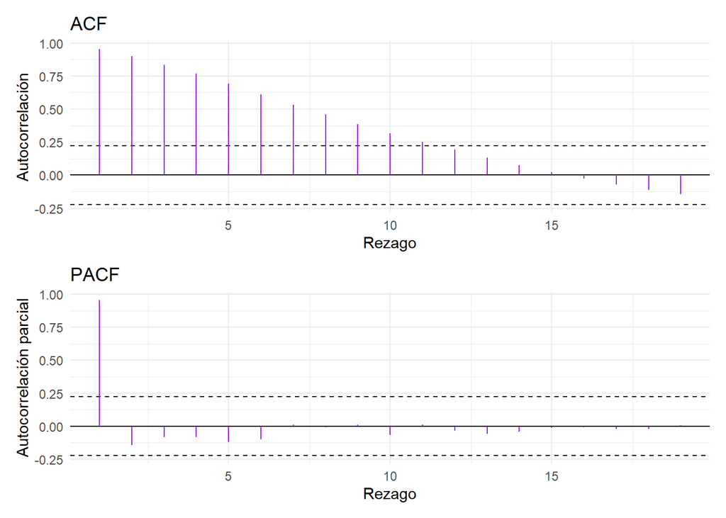

```r
resultado_errores_austres$correlograma$grafico
```

En el ACF, los primeros 11 rezagos se encuentran fuera de la banda de significancia, comenzando con una autocorrelación cercana a 1.0 y disminuyendo gradualmente hasta aproximadamente 0.2. Esto indica que los errores presentan una fuerte dependencia temporal en el corto plazo.

En el PACF, únicamente el primer rezago se encuentra fuera de la banda de significancia, mientras que los demás permanecen dentro. Esto sugiere que la dependencia directa entre errores se concentra principalmente en el primer rezago. Las autocorrelaciones observadas en los rezagos posteriores del ACF pueden estar relacionadas con la dependencia transmitida a través de ese primer rezago.

**Residuos vs valores ajustados**

**Mostrar/ocultar código**

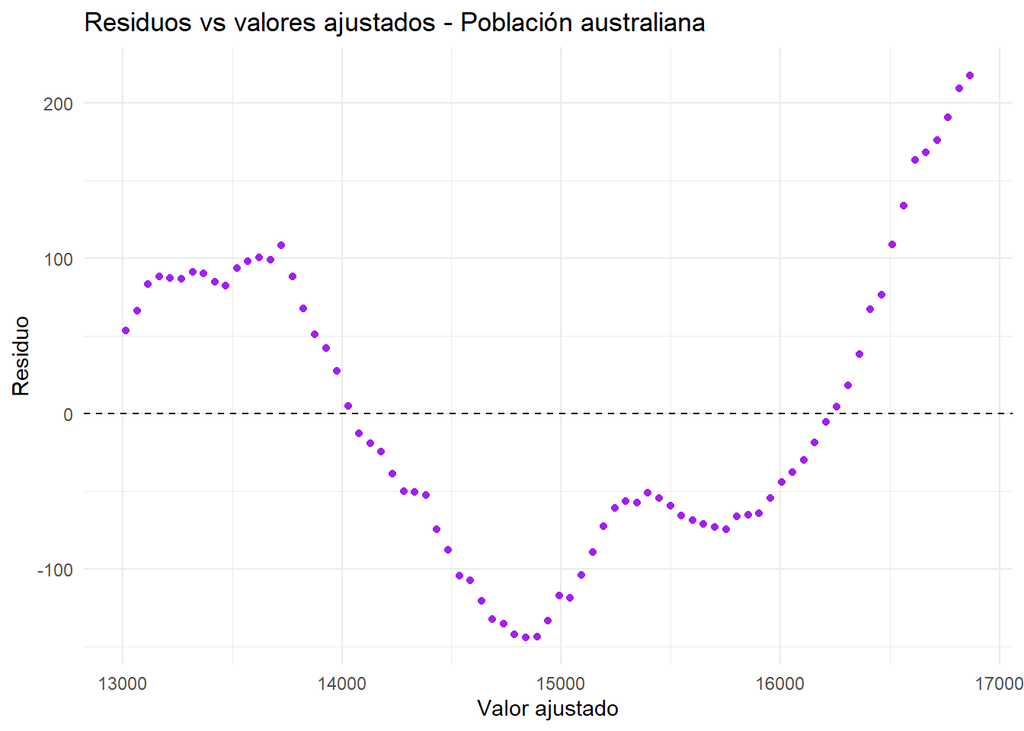

```r
# Residuos vs valores ajustados
datos_residuos_austres <- data.frame(
  ajustado = modelo_austres$yhat,
  residuo = modelo_austres$parametros$residuos
)

ggplot2::ggplot(
  datos_residuos_austres,
  ggplot2::aes(x = ajustado, y = residuo)
) +
  ggplot2::geom_point(color = "purple") +
  ggplot2::geom_hline(yintercept = 0, linetype = "dashed") +
  ggplot2::labs(
    title = "Residuos vs valores ajustados - Población australiana",
    x = "Valor ajustado",
    y = "Residuo"
  ) +
  ggplot2::theme_minimal()
```

Los residuos no se ven como una nube aleatoria, son positivos al inicio, bajan y se vuelven negativos en la parte media, y vuelven a subir con fuerza al final.

Esto muestra que el error no tiene varianza constante ni es independiente del nivel ajustado: hay un patrón claro, no ruido. Confirma lo mismo que ya se vio en el gráfico de errores en el tiempo.

**Prueba t (errores)**

Prueba de Hipótesis

$$H_0: \mu_e = 0$$
$$H_1: \mu_e \neq 0$$

Estadístico de Prueba:

$$t = \frac{\bar{e}}{s_e / \sqrt{77}}$$

Distribución bajo $H_0$

$$t \sim t_{76}$$

Región de Rechazo

$$|t| > t_{0.975,\,76}$$

**Mostrar/ocultar código**

```r
cat(
  "Estadístico de prueba:", round(resultado_errores_austres$t, 4), "\n",
  "Grados de libertad:", resultado_errores_austres$grados_libertad_t, "\n",
  "Valor crítico:", round(
    qt(0.975, resultado_errores_austres$grados_libertad_t), 4
  ), "\n",
  "Valor p:", round(resultado_errores_austres$valor_p_t, 4), "\n"
)
```

```
Estadístico de prueba: 0
 Grados de libertad: 76
 Valor crítico: 1.9917
 Valor p: 1
```

El estadístico dio exactamente 0, muy por debajo del valor crítico, con valor p = 1. No hay ningún indicio de que el modelo tienda a sobreestimar o subestimar en promedio. Con 76 grados de libertad, se evaluaron 77 errores.

**Ljung Box (errores)**

Prueba de Hipótesis

$$H_0:\rho_1=\rho_2=\cdots=\rho_{19}=0$$
$$H_1:\text{al menos una }\rho_h\neq0$$

Estadístico de Prueba

$$Q = T(T + 2) \sum_{h=1}^{19} \frac{{r}_h^2}{T - h}$$

Distribución

$$Q \sim \chi^2_{17}$$

Región de Rechazo

$$Q > \chi^2_{0.95, 17}$$

**Mostrar/ocultar código**

```r
cat(
  "Estadístico de prueba:", round(
    resultado_errores_austres$ljung_box$estadistico, 4
  ), "\n",
  "Grados de libertad:", resultado_errores_austres$ljung_box$grados_libertad, "\n",
  "Valor crítico:", round(
    resultado_errores_austres$ljung_box$valor_critico, 4
  ), "\n",
  "Valor p:", round(
    resultado_errores_austres$ljung_box$valor_p, 4
  ), "\n"
)
```

```
Estadístico de prueba: 399.4676
 Grados de libertad: 17
 Valor crítico: 27.5871
 Valor p: 0
```

Como (Q=399.47) supera ampliamente el valor crítico, se rechaza ($H_0$), con un valor p menor que 0.0001. Por lo tanto, hay evidencia estadísticamente significativa de que las autocorrelaciones de los errores, consideradas conjuntamente, no son todas iguales a cero. Esto indica que los errores todavía presentan una dependencia temporal importante y no se comportan completamente como ruido blanco.

**Jarque Bera**

Prueba de Hipótesis

$$H_0:\text{los errores tienen distribución normal}$$
$$H_1:\text{los errores no tienen distribución normal}$$

Distribución Bajo $H_0$:

$$JB \sim \chi^2_{2}$$

Estadístico de Prueba

$$JB = \frac{n}{6} \left( A^2 + \frac{(K - 3)^2}{4} \right)$$

Región de rechazo

$$JB>\chi^2_{0.95,2}$$

**Mostrar/ocultar código**

```r
cat(
  "Estadístico de prueba:", round(
    resultado_errores_austres$jarque_bera$estadistico, 4
  ), "\n",
  "Grados de libertad:", resultado_errores_austres$jarque_bera$grados_libertad, "\n",
  "Valor crítico:", round(
    resultado_errores_austres$jarque_bera$valor_critico, 4
  ), "\n",
  "Valor p:", format.pval(
    resultado_errores_austres$jarque_bera$valor_p,
    digits = 4
  ), "\n"
)
```

```
Estadístico de prueba: 4.2355
 Grados de libertad: 2
 Valor crítico: 5.9915
 Valor p: 0.1203
```

JB = 4.2355, por debajo del valor crítico, con valor p = 0.1203. No se encuentra evidencia contra la normalidad de los errores.

**Durbin Watson**

Prueba de Hipótesis:

$$H_0:\rho=0$$
$$H_1:\rho\neq0$$

Estadístico de Prueba:

$$DW=\frac{\sum_{t=2}^{n}(e_t-e_{t-1})^2} {\sum_{t=1}^{n}e_t^2}$$

**Mostrar/ocultar código**

```r
# Valores críticos de Durbin-Watson al 5%
tabla_dw <- data.frame(
  n = c(15, 20, 25, 30, 40, 50, 60, 70, 80, 90, 100),
  dL = c(1.08, 1.20, 1.29, 1.35, 1.44, 1.50, 1.55, 1.58, 1.61, 1.63, 1.65),
  dU = c(1.36, 1.41, 1.45, 1.49, 1.54, 1.59, 1.62, 1.64, 1.66, 1.68, 1.69)
)

# Número de residuos
n <- length(modelo_austres$parametros$residuos)

# Valores críticos aproximados para el n de la serie
dL <- approx(tabla_dw$n, tabla_dw$dL, xout = n)$y
dU <- approx(tabla_dw$n, tabla_dw$dU, xout = n)$y

# Estadístico Durbin-Watson
DW <- modelo_austres$parametros$DW

cat("n =", n, "\n",
    "DW =", round(DW, 4), "\n",
    "dL =", round(dL, 4), "\n",
    "dU =", round(dU, 4), "\n",
    "4 - dU =", round(4 - dU, 4), "\n",
    "4 - dL =", round(4 - dL, 4), "\n")
```

```
n = 77
 DW = 0.0171
 dL = 1.601
 dU = 1.654
 4 - dU = 2.346
 4 - dL = 2.399
```

Como $DW=0.0171<d_L=1.601$, se rechaza $H_0:\rho=0$ al 5 %. Por lo tanto, existe evidencia estadística de autocorrelación de primer orden en los errores. Además, como el estadístico DW es menor que $d_L$, la autocorrelación es positiva.

Como esta autocorrelación es positiva, el error estándar ordinario de los coeficientes queda subestimado, lo que infla el estadístico t y hace que los valores p ordinarios no sean confiables. Por esta razón, la significancia de los coeficientes $\beta_0$ y $\beta_1$ se evalúa con el error estándar robusto

**Prueba t coeficientes**

Prueba de Hipótesis:

$$H_0: \beta_j=0$$
$$H_0: \beta_j \neq 0$$
Estadístico de prueba:
$$t = \frac{\hat{\beta}_j}{SE_{\text{robusto}}(\hat{\beta}_j)}$$
Distribución bajo $H_0$:

$$t \sim t_{n-2}$$
Región de rechazo:

$$|t|> t_{0.975, n-2}$$

**Mostrar/ocultar código**

```r
#Prueba coeficientes
tabla_coef_austres <- modelo_austres$parametros$coeficientes

tabla_coef_austres$estimacion   <- round(tabla_coef_austres$estimacion, 4)
tabla_coef_austres$se_ordinario <- round(tabla_coef_austres$se_ordinario, 4)
tabla_coef_austres$se_robusto   <- round(tabla_coef_austres$se_robusto, 4)
tabla_coef_austres$t            <- round(tabla_coef_austres$t, 4)
tabla_coef_austres$valor_p      <- format.pval(tabla_coef_austres$valor_p, digits = 4, eps = 0.0001)

tabla_coef_austres
```

|  | coeficiente | estimacion | se_ordinario | se_robusto | t | valor_p |
| --- | --- | --- | --- | --- | --- | --- |
|  | beta_0 | 12963.2882 | 21.9579 | 40.7328 | 318.2520 | < 1e-04 |
| t | beta_1 | 50.7075 | 0.4892 | 1.0491 | 48.3365 | < 1e-04 |

Tanto el intercepto $\beta_0=12963.29$, con $t=318.25$, como la pendiente $\beta_1=50.71$, con $t=48.34$, resultan estadísticamente significativos, con valores p menores que 0.0001 en ambos casos. En particular, la pendiente es positiva y significativamente diferente de cero, lo que aporta evidencia de una tendencia creciente en la población. El valor estimado de $\beta_1=50.71$ indica que, en promedio, la población aumenta aproximadamente en 50.71 mil personas por trimestre.

**Gráfico Final**

**Mostrar/ocultar código**

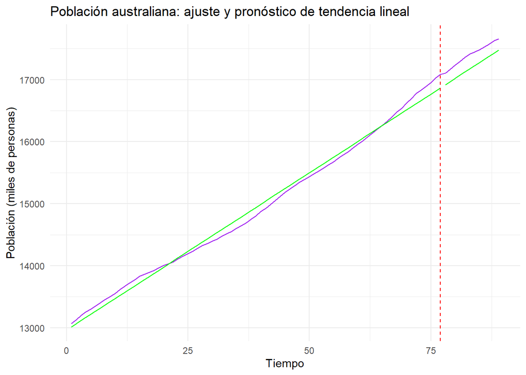

```r
ggplot2::ggplot(
  data.frame(
    tiempo = 1:T_austres,
    real = datos_austres$y,
    ajuste = c(modelo_austres$yhat, rep(NA, h_austres)),
    pronostico = c(rep(NA, T_austres - h_austres), pronosticos_austres)
  ),
  ggplot2::aes(x = tiempo)
) +

  # Serie real
  ggplot2::geom_line(
    ggplot2::aes(y = real),
    color = "purple"
  ) +

  # Ajuste de tendencia lineal
  ggplot2::geom_line(
    ggplot2::aes(y = ajuste),
    color = "green"
  ) +

  # Pronóstico
  ggplot2::geom_line(
    ggplot2::aes(y = pronostico),
    color = "green"
  ) +

  # Separación entre estimación y validación
  ggplot2::geom_vline(
    xintercept = T_austres - h_austres,
    color = "red",
    linetype = "dashed"
  ) +

  ggplot2::labs(
    title = "Población australiana: ajuste y pronóstico de tendencia lineal",
    x = "Tiempo",
    y = "Población (miles de personas)"
  ) +

  ggplot2::theme_minimal()
```

Antes de la línea roja, el ajuste sigue de cerca a la serie real, aunque con pequeñas desviaciones: la serie real queda un poco por debajo de la recta entre los periodos 25 y 65, y luego se despega hacia arriba con más fuerza cerca del final. En el tramo de validación, después de la línea roja, la serie real crece más rápido que el pronóstico, quedando por encima de la recta proyectada en todo el periodo.

Esto deja ver que, aunque el ajuste lineal es bueno en general, la población parece haber acelerado un poco su crecimiento hacia el final del periodo observado, algo que una recta fija no puede anticipar.

**Conclusión**

La población australiana fue modelada mediante una tendencia lineal, obteniendo un intercepto de $\beta_0=12963.29$ y una pendiente de $\beta_1=50.71$. Ambos coeficientes fueron estadísticamente significativos, con $t=318.25$ para el intercepto y $t=48.34$ para la pendiente, y valores p menores que 0.0001. La pendiente positiva indica un incremento promedio de aproximadamente 50.71 mil personas por trimestre. Sin embargo, el modelo no logra capturar toda la dinámica temporal de la serie: la prueba de Ljung-Box sobre los errores produjo $Q=399.47$, con un valor p menor que 0.0001, mientras que el estadístico de Durbin-Watson fue $0.0171$, lo que sugiere una fuerte autocorrelación positiva entre errores consecutivos. Además, el correlograma de los errores mostró varios rezagos significativos en el ACF y el primer rezago significativo en el PACF.

Los resultados pueden ser de utilidad para entidades encargadas de la planeación demográfica y territorial, especialmente para anticipar necesidades de vivienda, infraestructura y servicios públicos. La pendiente estimada de 50.71 mil personas por trimestre permite utilizar el modelo como una referencia de crecimiento en horizontes cortos. Sin embargo, el valor de $DW=0.0171$ y el resultado de Ljung-Box $Q=399.47$, $p<0.0001$ muestran que la evolución de la población contiene una dependencia temporal que la recta no captura, por lo que para decisiones de mayor plazo sería preferible complementar este pronóstico con un modelo que incorpore dicha dependencia.

### 3.6 Millas de Pasajeros

**Descripción de la serie**

**Mostrar/ocultar código**

```r
propiedades_airmiles <- data.frame(
  Métrica    = c("Longitud de la serie (n)",
                 "Año de inicio",
                 "Año de fin",
                 "Frecuencia observada"),
  Valor      = c(length(datos_airmiles$y),
                 start(airmiles)[1],
                 end(airmiles)[1],
                 frequency(airmiles)),
  Descripción = c("Número total de observaciones anuales",
                  "Primer año registrado en la serie",
                  "Último año registrado en la serie",
                  "Frecuencia anual de medición (1 dato/año)"),
  stringsAsFactors = FALSE
)

kable(propiedades_airmiles,
      format    = "html",
      col.names = c("Métrica", "Valor", "Descripción"),
      align     = c("l", "c", "l"),
      caption   = "Propiedades temporales — Serie de Millas de Pasajeros") |>
  kable_styling(bootstrap_options = "basic",
                full_width         = FALSE,
                position          = "center") |>
  row_spec(0, bold = TRUE) |>
  row_spec(1:nrow(propiedades_airmiles), extra_css = "border-bottom: none;") |>
  column_spec(1:3, border_left = FALSE, border_right = FALSE) |>
  add_header_above(c(" " = 3), line = TRUE, bold = TRUE) |>
  row_spec(nrow(propiedades_airmiles), extra_css = "border-bottom: 1px solid black;")
```

Propiedades temporales — Serie de Millas de Pasajeros

| Métrica | Valor | Descripción |
| --- | --- | --- |
| Longitud de la serie (n) | 24 | Número total de observaciones anuales |
| Año de inicio | 1937 | Primer año registrado en la serie |
| Año de fin | 1960 | Último año registrado en la serie |
| Frecuencia observada | 1 | Frecuencia anual de medición (1 dato/año) |

La serie de Millas de Pasajeros tiene 24 observaciones en total, con frecuencia anual, incia en 1937 y termina en 1960

**Exploración de la serie**

**Gráficos**

**Mostrar/ocultar código**

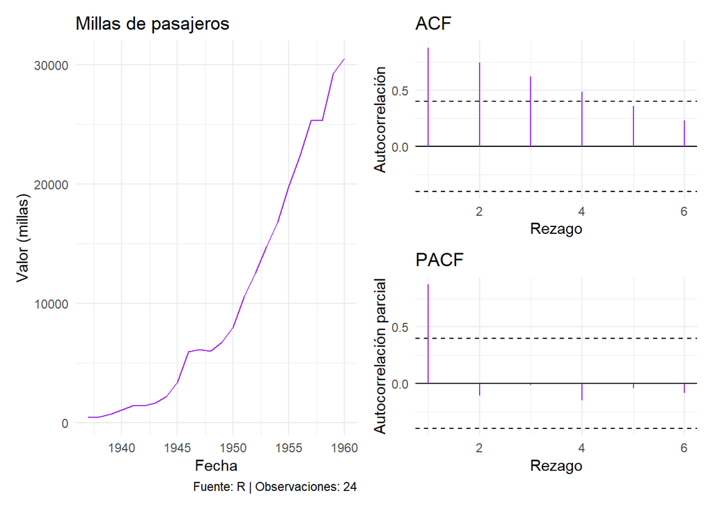

```r
datos_airmiles <- leer_serie(
  airmiles,
  fuente = "R",
  unidad = "millas"
)

grafico_airmiles <- graficar_serie(
  datos_airmiles,
  "Millas de pasajeros"
)

cor_airmiles <- correlograma(
  datos_airmiles$y
)

panel_airmiles <- panel_diagnostico(
  grafico_airmiles,
  cor_airmiles
)

print(panel_airmiles)
```

La serie tiene tendencia, no presenta estacionalidad y debido al cambio de nivel no es estacionaria

**Contraste individual de los \(r_h\)**

Prueba de Hipótesis

$$H_0:\rho_h=0$$
$$H_1:\rho_h\neq0$$

Estadístico de Prueba:

$$Z_h=\frac{r_h}{1/\sqrt{24}}$$

Distribución bajo $H_0$:

$$Z_h\sim N(0,1)$$

Región de rechazo al 5 %:

$$|Z_h|>1.96$$

**Mostrar/ocultar código**

```r
#Constrastes Individuales
r_airmiles <- cor_airmiles$acf

T_airmiles <- length(datos_airmiles$y)

z_airmiles <- r_airmiles * sqrt(T_airmiles)

valor_p_airmiles <- 2 * pnorm(-abs(z_airmiles))

valor_critico_airmiles <- qnorm(0.975)
```

**Mostrar/ocultar código**

```r
tabla_acf_airmiles <- data.frame(
  rezago = 1:length(r_airmiles),
  r_h = r_airmiles,
  estadistico = z_airmiles,
  valor_p = valor_p_airmiles,
  significativo = abs(z_airmiles) > valor_critico_airmiles
)
```

**Mostrar/ocultar código**

```r
tabla_acf_airmiles_formato <- tabla_acf_airmiles
tabla_acf_airmiles_formato$r_h         <- round(tabla_acf_airmiles_formato$r_h, 4)
tabla_acf_airmiles_formato$estadistico <- round(tabla_acf_airmiles_formato$estadistico, 4)
tabla_acf_airmiles_formato$valor_p     <- format.pval(tabla_acf_airmiles_formato$valor_p, digits = 4, eps = 0.0001)
tabla_acf_airmiles_formato$significativo <- ifelse(tabla_acf_airmiles_formato$significativo, "Sí", "No")
```

**Mostrar/ocultar código**

```r
kable(tabla_acf_airmiles_formato,
      format    = "html",
      col.names = c("Rezago ($h$)", "Autocorrelación ($r_h$)", "Estadístico ($z$)", "Valor $p$", "Significativo"),
      align     = c("c", "c", "c", "c", "c"),
      caption   = "Contraste individual de autocorrelación — Serie de Millas de Pasajeros") |>
  kable_styling(bootstrap_options = "basic",
                full_width         = FALSE,
                position          = "center") |>
  row_spec(0, bold = TRUE) |>
  row_spec(1:nrow(tabla_acf_airmiles_formato), extra_css = "border-bottom: none;") |>
  column_spec(1:5, border_left = FALSE, border_right = FALSE) |>
  add_header_above(c(" " = 5), line = TRUE, bold = TRUE) |>
  row_spec(nrow(tabla_acf_airmiles_formato), extra_css = "border-bottom: 1px solid black;")
```

Contraste individual de autocorrelación — Serie de Millas de Pasajeros

| Rezago ($h$) | Autocorrelación ($r_h$) | Estadístico ($z$) | Valor $p$ | Significativo |
| --- | --- | --- | --- | --- |
| 1 | 0.8761 | 4.2920 | < 1e-04 | Sí |
| 2 | 0.7422 | 3.6359 | 0.000277 | Sí |
| 3 | 0.6221 | 3.0476 | 0.002306 | Sí |
| 4 | 0.4849 | 2.3754 | 0.017532 | Sí |
| 5 | 0.3559 | 1.7434 | 0.081264 | No |
| 6 | 0.2320 | 1.1364 | 0.255800 | No |

Los rezagos 1 a 4 son estadísticamente significativos, con autocorrelaciones positivas que disminuyen de 0.8761 en el rezago 1 a 0.4849 en el rezago 4. En cambio, los rezagos 5 y 6 no presentan evidencia estadísticamente significativa de autocorrelación, ya que sus valores p son mayores que 0.05.

La disminución de las autocorrelaciones es relativamente rápida y no se observa un cambio de signo en los primeros seis rezagos. Este comportamiento indica una dependencia temporal importante entre observaciones cercanas y es compatible con la presencia de una tendencia en la serie.

**Ljung Box**

Prueba Hipótesis

$$H_0:\rho_1=\rho_2=\cdots=\rho_{6}=0$$
$$H_1:\text{al menos una }\rho_h\neq0$$

Estadístico de Prueba

$$Q = 24(24 + 2) \sum_{h=1}^{6} \frac{{r}_h^2}{24 - h}$$

Distribución

$$Q \sim \chi^2_{6}$$

Región de Rechazo

$$Q > \chi^2_{0.95, 6}$$

**Mostrar/ocultar código**

```r
resultado_lb_airmiles <- ljung_box(
  r = cor_airmiles$acf,
  T = length(datos_airmiles$y),
  m = length(cor_airmiles$acf),
  p = 0
)

cat(
  "Millas de pasajeros → Q =", round(resultado_lb_airmiles$estadistico, 4),
  "| gl =", resultado_lb_airmiles$grados_libertad,
  "| valor crítico =", round(resultado_lb_airmiles$valor_critico, 4),
  "| p-valor =", round(resultado_lb_airmiles$valor_p, 4), "\n"
)
```

```
Millas de pasajeros → Q = 61.3067 | gl = 6 | valor crítico = 12.5916 | p-valor = 0
```

Como (Q=61.31) es mucho mayor que el valor crítico (12.5916), se rechaza ($H_0$), con un valor p menor que 0.0001. Por lo tanto, hay evidencia estadísticamente significativa de que las autocorrelaciones, consideradas conjuntamente hasta el rezago analizado, no son todas iguales a cero.

En consecuencia, la serie no es ruido blanco y presenta una dependencia temporal importante. Este resultado es consistente con los contrastes individuales, donde los primeros cuatro rezagos presentaron autocorrelaciones positivas y significativas

**Estimación y Validación**

**Partición de la serie**

**Mostrar/ocultar código**

```r
#Particion de la serie
h_airmiles <- min(
  12,
  floor(0.2 * T_airmiles)
)

y_estimacion_airmiles <- datos_airmiles$y[1:(T_airmiles - h_airmiles)]

y_validacion_airmiles <- datos_airmiles$y[(T_airmiles - h_airmiles + 1):T_airmiles]

cat(
  "Millas de pasajeros → Estimación =", length(y_estimacion_airmiles),
  "| Validación =", length(y_validacion_airmiles), "\n"
)
```

```
Millas de pasajeros → Estimación = 20 | Validación = 4
```

La serie de Millas de pasajeros tiene 24 observaciones en total. Se usaron 20 para estimar el modelo y las últimas 4 para validarlo.

**Tendencia cuadrática**

**Mostrar/ocultar código**

```r
modelo_airmiles <- ajustar_tendencia(
  y_estimacion_airmiles,
  "cuadratica"
)

pronosticos_airmiles <- modelo_airmiles$pronosticar(h_airmiles)

cat(
  "Horizonte de validación (h):", h_airmiles, "\n",
  "Pronósticos:", round(pronosticos_airmiles, 4), "\n"
)
```

```
Horizonte de validación (h): 4
 Pronósticos: 24246.78 26969 29839.89 32859.43
```

El pronóstico aumenta de 24,246.78 en $h=1$ a 32,859.43 en $h=4$. Además, los incrementos entre pronósticos son cada vez mayores, aproximadamente 2.722, 2.871 y 3.020. Esto ocurre porque la tendencia cuadrática no supone un crecimiento a una cantidad constante por período, sino que permite que la pendiente cambie con el tiempo.

En este caso, los incrementos crecientes indican que la serie presenta una tendencia ascendente con aceleración. Este comportamiento es coherente con la forma curva observada en el gráfico de la serie y es precisamente lo que la tendencia cuadrática busca representar.

**Medidas de error**

**Mostrar/ocultar código**

```r
# Medidas de error en el período de estimación (ajuste)
posiciones_airmiles <- which(!is.na(modelo_airmiles$yhat))

medidas_estimacion_airmiles <- medidas(
  y = y_estimacion_airmiles[posiciones_airmiles],
  yhat = modelo_airmiles$yhat[posiciones_airmiles]
)
```

**Mostrar/ocultar código**

```r
# Medidas de error en el período de validación
medidas_validacion_airmiles <- medidas(
  y = y_validacion_airmiles,
  yhat = pronosticos_airmiles
)
```

**Mostrar/ocultar código**

```r
# Pronósticos del método ingenuo
pronosticos_ingenuo_airmiles <- rep(
  y_estimacion_airmiles[length(y_estimacion_airmiles)],
  h_airmiles
)
```

**Mostrar/ocultar código**

```r
# Medidas de error del ingenuo
medidas_ingenuo_airmiles <- medidas(
  y = y_validacion_airmiles,
  yhat = pronosticos_ingenuo_airmiles
)
```

**Mostrar/ocultar código**

```r
# Escala del MASE usando el ingenuo en estimación
escala_mase_airmiles <- mean(
  abs(
    y_estimacion_airmiles[2:length(y_estimacion_airmiles)] -
    y_estimacion_airmiles[1:(length(y_estimacion_airmiles) - 1)]
  )
)

# MASE correcto de cada método (estimación y validación)
mase_estim_airmiles <- medidas_estimacion_airmiles$MAD / escala_mase_airmiles
mase_valid_airmiles <- medidas_validacion_airmiles$MAD / escala_mase_airmiles
mase_ingenuo_airmiles <- medidas_ingenuo_airmiles$MAD / escala_mase_airmiles
```

**Mostrar/ocultar código**

```r
# Tabla única de comparación
tabla_medidas_airmiles <- data.frame(
  Tramo = c("Estimación", "Validación", "Validación"),
  Método = c("Tendencia cuadrática", "Tendencia cuadrática", "Ingenuo"),
  MSE = c(
    medidas_estimacion_airmiles$MSE,
    medidas_validacion_airmiles$MSE,
    medidas_ingenuo_airmiles$MSE
  ),
  MAD = c(
    medidas_estimacion_airmiles$MAD,
    medidas_validacion_airmiles$MAD,
    medidas_ingenuo_airmiles$MAD
  ),
  MAPE = c(
    medidas_estimacion_airmiles$MAPE,
    medidas_validacion_airmiles$MAPE,
    medidas_ingenuo_airmiles$MAPE
  ),
  MASE = c(
    mase_estim_airmiles,
    mase_valid_airmiles,
    mase_ingenuo_airmiles
  )
)

tabla_medidas_airmiles
```

| Tramo | Método | MSE | MAD | MAPE | MASE |
| --- | --- | --- | --- | --- | --- |
| Estimación | Tendencia cuadrática | 472846.5 | 518.4537 | 20.565385 | 0.4436018 |
| Validación | Tendencia cuadrática | 2416497.7 | 1408.8869 | 5.091777 | 1.2054783 |
| Validación | Ingenuo | 32979149.5 | 5254.5000 | 18.457185 | 4.4958795 |

En el período de estimación, el modelo obtuvo un MSE de 472846.5, un MAD de 518.45, un MAPE de 20.57% y un MASE de 0.4436. El MASE menor que 1 indica que, dentro del tramo de estimación, el modelo presentó un error absoluto menor que la referencia ingenua utilizada para calcular la escala. En conjunto, las métricas indican un ajuste razonable dentro de la muestra.

En el período de validación, el MSE aumentó a 2416497.7 y el MAD a 1408.89, mientras que el MAPE disminuyó a 5.09% y el MASE a 1.2055. El aumento del MSE y del MAD indica que el modelo tuvo mayores errores absolutos al enfrentarse a observaciones nuevas, algo que puede ocurrir al pasar del ajuste a la predicción fuera de muestra. Al mismo tiempo, la disminución del MAPE muestra que, en términos relativos al valor observado, el error porcentual fue menor en la validación.

Al comparar la tendencia cuadrática con el método ingenuo en el mismo período de validación, la tendencia cuadrática obtuvo un MSE de 2416497.7 frente a 32979149.5 del ingenuo, y un MASE de 1.21 frente a 4.50. Por lo tanto, la tendencia cuadrática presentó menores errores de validación que el método ingenuo. Esto es consistente con el fuerte crecimiento observado en la serie, ya que el método ingenuo utiliza principalmente la última observación y no incorpora explícitamente la aceleración de la tendencia, mientras que la tendencia cuadrática permite que el crecimiento cambie con el tiempo.

**Validación de los errores**

Para la validación de errores se utilizaron 20 errores

**Mostrar/ocultar código**

```r
posiciones_airmiles <- which(!is.na(modelo_airmiles$yhat))

errores_airmiles <- y_estimacion_airmiles[posiciones_airmiles] - modelo_airmiles$yhat[posiciones_airmiles]

resultado_errores_airmiles <- validar_errores(
  e = errores_airmiles,
  m = NULL,
  p = 3    # tendencia cuadrática: 3 parámetros (intercepto, lineal, cuadrático)
)
```

**Gráfico**

**Mostrar/ocultar código**

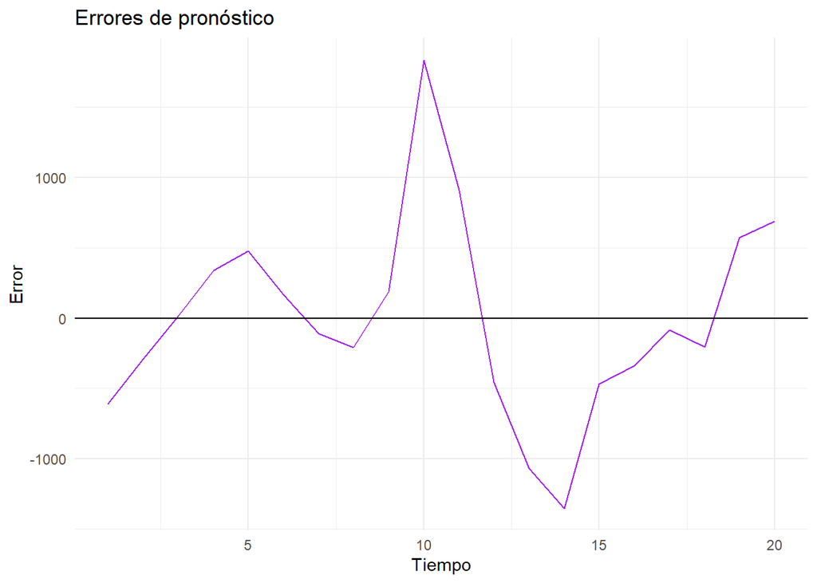

```r
resultado_errores_airmiles$grafico_errores
```

**Correlograma**

**Mostrar/ocultar código**

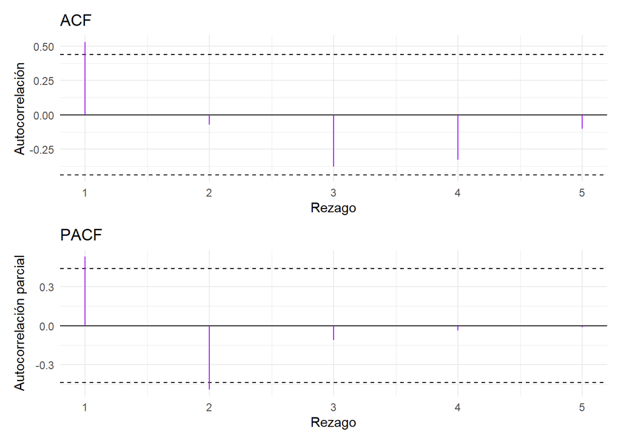

```r
resultado_errores_airmiles$correlograma$grafico
```

En el ACF, el rezago 1 supera la banda de significancia, por lo que presenta evidencia de autocorrelación estadísticamente significativa. Los rezagos 3 y 4 también se encuentran relativamente cerca de la banda inferior, con valores aproximados de $-0.35$ y $-0.30$, aunque no la superan.

En el PACF, los rezagos 1 y 2 superan las bandas de significancia, indicando evidencia de autocorrelación parcial significativa en estos rezagos. Los demás rezagos no cruzan las bandas, aunque algunos se encuentran relativamente cerca de ellas.

Estos resultados son consistentes con la prueba de Ljung-Box, que rechazó la hipótesis de ruido blanco. Por lo tanto, existe evidencia de dependencia temporal en los errores. En particular, el ACF muestra dependencia en el primer rezago y el PACF indica que, después de considerar los rezagos anteriores, todavía existe una relación importante hasta el segundo rezago.

**Residuos vs valores ajustados**

**Mostrar/ocultar código**

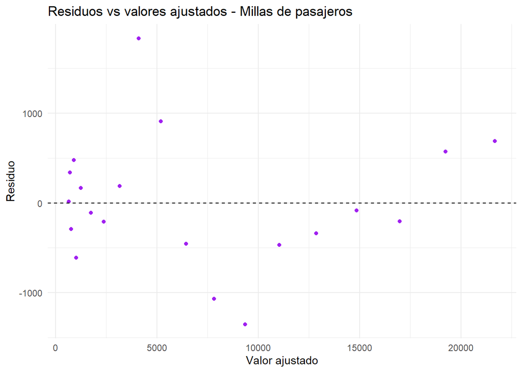

```r
datos_residuos_airmiles <- data.frame(
  ajustado = modelo_airmiles$yhat[posiciones_airmiles],
  residuo = errores_airmiles
)

ggplot2::ggplot(
  datos_residuos_airmiles,
  ggplot2::aes(x = ajustado, y = residuo)
) +
  ggplot2::geom_point(color = "purple") +
  ggplot2::geom_hline(yintercept = 0, linetype = "dashed") +
  ggplot2::labs(
    title = "Residuos vs valores ajustados - Millas de pasajeros",
    x = "Valor ajustado",
    y = "Residuo"
  ) +
  ggplot2::theme_minimal()
```

Los residuos no muestran una curva clara, pero tampoco se ven del todo al azar. Hay un punto muy alejado del resto, mucho más grande que los demás.

La dispersión es mayor en los valores ajustados bajos que en los altos, donde los residuos son más pequeños. Esto sugiere que la varianza del error no es del todo constante.

**Prueba t**

Prueba de Hipótesis

$$H_0: \mu_e = 0$$
$$H_1: \mu_e \neq 0$$

Estadístico de Prueba:

$$t = \frac{\bar{e}}{s_e / \sqrt{20}}$$

Distribución bajo $H_0$

$$t \sim t_{19}$$

Región de Rechazo

$$|t| > t_{0.975,\,19}$$

**Mostrar/ocultar código**

```r
cat(
  "Estadístico de prueba:", round(resultado_errores_airmiles$t, 4), "\n",
  "Grados de libertad:", resultado_errores_airmiles$grados_libertad_t, "\n",
  "Valor crítico:", round(
    qt(0.975, resultado_errores_airmiles$grados_libertad_t), 4
  ), "\n",
  "Valor p:", round(resultado_errores_airmiles$valor_p_t, 4), "\n"
)
```

```
Estadístico de prueba: 0
 Grados de libertad: 19
 Valor crítico: 2.093
 Valor p: 1
```

Como (|t|=0) es menor que el valor crítico (2.093), no se rechaza ($H_0$), con un valor p de 1. Por lo tanto, no hay evidencia estadísticamente significativa de que la media de los errores sea diferente de cero. Esto indica que los errores están centrados en cero, en promedio, y no se observa evidencia de sesgo sistemático en los pronósticos.

**Ljung Box**

Prueba de Hipótesis

$$H_0:\rho_1=\rho_2=\cdots=\rho_{5}=0$$
$$H_1:\text{al menos una }\rho_h\neq0$$

Estadístico de Prueba

$$Q = 20(20 + 2) \sum_{h=1}^{5} \frac{{r}_h^2}{20 - h}$$

Distribución

$$Q \sim \chi^2_{2}$$

Región de Rechazo

$$Q > \chi^2_{0.95, 2}$$

**Mostrar/ocultar código**

```r
cat(
  "Estadístico de prueba:", round(
    resultado_errores_airmiles$ljung_box$estadistico, 4
  ), "\n",
  "Grados de libertad:", resultado_errores_airmiles$ljung_box$grados_libertad, "\n",
  "Valor crítico:", round(
    resultado_errores_airmiles$ljung_box$valor_critico, 4
  ), "\n",
  "Valor p:", round(
    resultado_errores_airmiles$ljung_box$valor_p, 4
  ), "\n"
)
```

```
Estadístico de prueba: 13.6329
 Grados de libertad: 2
 Valor crítico: 5.9915
 Valor p: 0.0011
```

Como (Q=13.6329) es mayor que el valor crítico (5.9915), se rechaza $H_0$, con un valor p de (0.0011). Por lo tanto, hay evidencia estadísticamente significativa de que las autocorrelaciones de los errores, consideradas en conjunto, no son todas iguales a cero. Esto indica que todavía existe dependencia temporal en los errores y que estos no se comportan completamente como ruido blanco.

**Jarque Bera**

Prueba de Hipótesis

$$H_0:\text{los errores tienen distribución normal}$$
$$H_1:\text{los errores no tienen distribución normal}$$

Distribución Bajo $H_0$:

$$JB \sim \chi^2_{2}$$

Estadístico de Prueba

$$JB = \frac{20}{6} \left( A^2 + \frac{(K - 3)^2}{4} \right)$$

Región de rechazo

$$JB>\chi^2_{0.95,2}$$

**Mostrar/ocultar código**

```r
cat(
  "Estadístico de prueba:", round(
    resultado_errores_airmiles$jarque_bera$estadistico, 4
  ), "\n",
  "Grados de libertad:", resultado_errores_airmiles$jarque_bera$grados_libertad, "\n",
  "Valor crítico:", round(
    resultado_errores_airmiles$jarque_bera$valor_critico, 4
  ), "\n",
  "Valor p:", format.pval(
    resultado_errores_airmiles$jarque_bera$valor_p,
    digits = 4
  ), "\n"
)
```

```
Estadístico de prueba: 1.5357
 Grados de libertad: 2
 Valor crítico: 5.9915
 Valor p: 0.464
```

Como JB = 1.5357 es menor que el valor crítico 5.9915, no se rechaza $H_0$, con un valor p de 0.464. No hay evidencia de que los errores se alejen de la normalidad. Sin embargo, con n = 20 errores, apenas en el límite del umbral señalado, esta prueba asintótica debe interpretarse con cautela.

**Durbin Watson**

Prueba de Hipótesis:

$$H_0:\rho=0$$
$$H_1:\rho\neq0$$

Estadístico de Prueba:

$$DW=\frac{\sum_{t=2}^{20}(e_t-e_{t-1})^2} {\sum_{t=1}^{20}e_t^2}$$

**Mostrar/ocultar código**

```r
# Valores críticos de Durbin-Watson al 5%
tabla_dw <- data.frame(
  n = c(15, 20, 25, 30, 40, 50, 60, 70, 80, 90, 100),
  dL = c(1.08, 1.20, 1.29, 1.35, 1.44, 1.50, 1.55, 1.58, 1.61, 1.63, 1.65),
  dU = c(1.36, 1.41, 1.45, 1.49, 1.54, 1.59, 1.62, 1.64, 1.66, 1.68, 1.69)
)

# Número de errores
n <- length(modelo_airmiles$parametros$residuos)

# Valores críticos aproximados
dL <- approx(tabla_dw$n, tabla_dw$dL, xout = n)$y
dU <- approx(tabla_dw$n, tabla_dw$dU, xout = n)$y

# Estadístico Durbin-Watson
DW <- modelo_airmiles$parametros$DW

cat("n =", n, "\n",
    "DW =", round(DW, 4), "\n",
    "dL =", round(dL, 4), "\n",
    "dU =", round(dU, 4), "\n",
    "4 - dU =", round(4 - dU, 4), "\n",
    "4 - dL =", round(4 - dL, 4), "\n")
```

```
n = 20
 DW = 0.8489
 dL = 1.2
 dU = 1.41
 4 - dU = 2.59
 4 - dL = 2.8
```

Como DW=0.8489 es menor que dL=1.2, se rechaza la hipótesis nula. Hay evidencia de autocorrelación de primer orden en los errores, y como DW es menor que dL, la autocorrelación es positiva.

Como la autocorrelación es positiva, el error estándar ordinario de los coeficientes queda subestimado, lo que infla el estadístico t y hace que los valores p ordinarios no sean confiables. Por eso la significancia de $\beta_0$, $\beta_1$ y $\beta_2$ se evalúa con el error estándar robusto.

**Pruebas t sobre los coeficientes (error estándar robusto)**

Prueba de Hipótesis:

$$H_0: \beta_j=0$$

$$H_0: \beta_j \neq 0$$

Estadístico de prueba:
$$t = \frac{\hat{\beta}_j}{SE_{\text{robusto}}(\hat{\beta}_j)}$$

Distribución bajo $H_0$:

$$t \sim t_{n-3}$$

Región de rechazo:

$$|t|> t_{0.975, n-3}$$

**Mostrar/ocultar código**

```r
tabla_coef_airmiles <- modelo_airmiles$parametros$coeficientes

tabla_coef_airmiles$estimacion   <- round(tabla_coef_airmiles$estimacion, 4)
tabla_coef_airmiles$se_ordinario <- round(tabla_coef_airmiles$se_ordinario, 4)
tabla_coef_airmiles$se_robusto   <- round(tabla_coef_airmiles$se_robusto, 4)
tabla_coef_airmiles$t            <- round(tabla_coef_airmiles$t, 4)
tabla_coef_airmiles$valor_p      <- format.pval(tabla_coef_airmiles$valor_p, digits = 4, eps = 0.0001)

tabla_coef_airmiles
```

| coeficiente | estimacion | se_ordinario | se_robusto | t | valor_p |
| --- | --- | --- | --- | --- | --- |
| beta_0 | 1420.1246 | 554.8976 | 517.1624 | 2.7460 | 0.01378 |
| beta_1 | -473.9304 | 121.6976 | 149.3568 | -3.1731 | 0.00556 |
| beta_2 | 74.3292 | 5.6291 | 6.8758 | 10.8103 | < 1e-04 |

Los tres coeficientes del modelo son estadísticamente significativos: $\beta_0=1420.12$ $t=2.746$, $p=0.01378$, $\beta_1=-473.93$, $t=-3.173$, $p=0.00556$ y $\beta_2=74.33$ $t=10.81$, $p<0.0001$. En particular, el coeficiente cuadrático es positivo y significativo, lo que indica que la relación entre el tiempo y la serie presenta una curvatura hacia arriba. Esto es coherente con el gráfico y permite representar un crecimiento que se acelera a medida que avanza el tiempo, en lugar de un crecimiento lineal a una tasa constante.

**Gráfico Final**

**Mostrar/ocultar código**

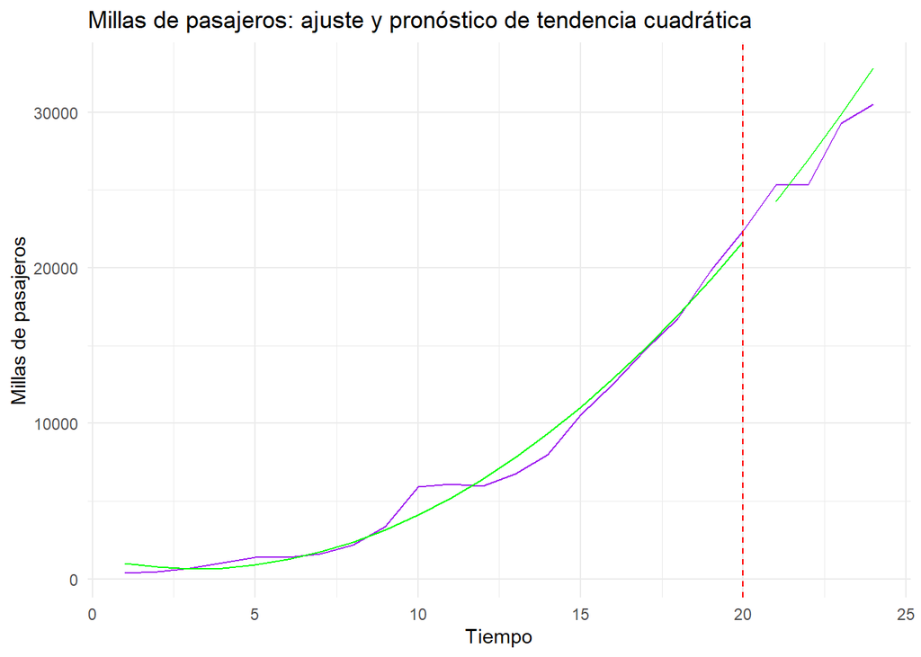

```r
ggplot2::ggplot(
  data.frame(
    tiempo = 1:T_airmiles,
    real = datos_airmiles$y,
    ajuste = c(modelo_airmiles$yhat, rep(NA, h_airmiles)),
    pronostico = c(rep(NA, T_airmiles - h_airmiles), pronosticos_airmiles)
  ),
  ggplot2::aes(x = tiempo)
) +

  ggplot2::geom_line(
    ggplot2::aes(y = real),
    color = "purple"
  ) +

  ggplot2::geom_line(
    ggplot2::aes(y = ajuste),
    color = "green"
  ) +

  ggplot2::geom_line(
    ggplot2::aes(y = pronostico),
    color = "green"
  ) +

  ggplot2::geom_vline(
    xintercept = T_airmiles - h_airmiles,
    color = "red",
    linetype = "dashed"
  ) +

  ggplot2::labs(
    title = "Millas de pasajeros: ajuste y pronóstico de tendencia cuadrática",
    x = "Tiempo",
    y = "Millas de pasajeros"
  ) +

  ggplot2::theme_minimal()
```

Durante el tramo de estimación, antes de la línea punteada, el ajuste sigue razonablemente bien la forma general de la serie real, aunque no logra capturar completamente el salto puntual observado cerca del tiempo 10.

En el tramo de validación, después de la línea punteada, el pronóstico mantiene una curva creciente y suave, mientras que la serie real presenta un comportamiento más irregular, con un tramo casi plano entre los tiempos 20 y 22 y posteriormente un aumento marcado al final. Además, el pronóstico se mantiene por encima de los valores reales durante gran parte del período de validación.

Esto muestra una de las principales limitaciones de la tendencia cuadrática: el modelo logra representar la tendencia general y la aceleración del crecimiento, pero tiene dificultades para adaptarse a cambios puntuales o cambios en el ritmo de crecimiento que no estaban presentes en el tramo utilizado para la estimación.

**Conclusión**

La serie de millas de pasajeros fue modelada mediante una tendencia cuadrática, cuyos coeficientes fueron $\beta_0=1420.12$, $\beta_1=-473.93$ y $\beta_2=74.33$. Los tres resultaron significativos, con valores p de $0.01378$, $0.00556$ y $<0.0001$, respectivamente. El coeficiente cuadrático positivo permite representar la aceleración del crecimiento observada en la serie. En validación, el modelo obtuvo un MSE de $2416497.7$, un MAD de $1408.89$, un MAPE de $5.09\%$ y un MASE de $1.2055$, todos inferiores a los obtenidos por el método ingenuo. Esto muestra que la curva cuadrática logró seguir mejor el crecimiento de los pasajeros que una referencia basada únicamente en la última observación.

La principal dificultad aparece en los errores: el Ljung-Box produjo $Q=13.6329$, con $p=0.0011$, y el Durbin-Watson fue $0.8489$, evidenciando que todavía queda dependencia temporal. Además, el gráfico final muestra que el modelo sigue una trayectoria suave mientras la serie presenta cambios bruscos de ritmo.

Este modelo puede resultar útil para aerolíneas y entidades de planificación del transporte que necesiten una referencia sobre la evolución creciente del tráfico de pasajeros. Por su capacidad para representar una tendencia acelerada, puede emplearse en horizontes cortos de hasta 4 períodos. Sin embargo, ante cambios repentinos en el número de pasajeros, sus pronósticos pueden desviarse considerablemente, por lo que no debería utilizarse como única herramienta para decisiones que requieran alta precisión.

### 3.7 Ganancias de Johnson & Johnson

**Descripción de la serie**

**Mostrar/ocultar código**

```r
#Descripción de la serie
propiedades_J <- data.frame(
  Métrica    = c("Longitud de la serie (n)",
                 "Año de inicio",
                 "Año de fin",
                 "Frecuencia observada"),
  Valor      = c(length(datos_J$y),
                 start(JohnsonJohnson)[1],
                 end(JohnsonJohnson)[1],
                 frequency(JohnsonJohnson)),
  Descripción = c("Número total de observaciones trimestrales",
                  "Primer año registrado en la serie",
                  "Último año registrado en la serie",
                  "Frecuencia trimestral de medición (4 datos/año)"),
  stringsAsFactors = FALSE
)

propiedades_J
```

| Métrica | Valor | Descripción |
| --- | --- | --- |
| Longitud de la serie (n) | 84 | Número total de observaciones trimestrales |
| Año de inicio | 1960 | Primer año registrado en la serie |
| Año de fin | 1980 | Último año registrado en la serie |
| Frecuencia observada | 4 | Frecuencia trimestral de medición (4 datos/año) |

La serie tiene 84 observaciones trimestrales, desde 1960 hasta 1980, con una frecuencia de 4 datos por año.

**Exploración de la serie**

**Gráficos**

**Mostrar/ocultar código**

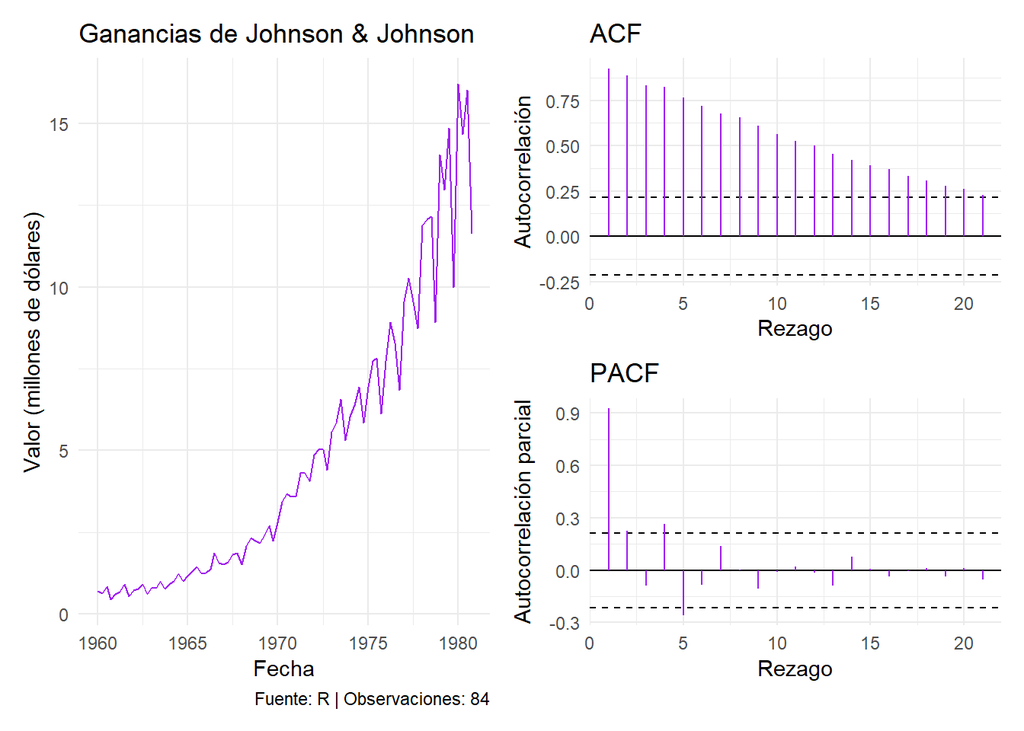

```r
datos_J <- leer_serie(
  JohnsonJohnson,
  fuente = "R",
  unidad = "millones de dólares"
)

grafico_J <- graficar_serie(
  datos_J,
  "Ganancias de Johnson & Johnson"
)

cor_J <- correlograma(
  datos_J$y
)

panel_J <- panel_diagnostico(
  grafico_J,
  cor_J
)

print(panel_J)
```

La serie tiene tendencia y no presenta estacionalidad clara.

**Contraste individual de los \(r_h\)**

Prueba de Hipótesis

$$H_0:\rho_h=0$$
$$H_1:\rho_h\neq0$$

Estadístico de Prueba:

$$Z_h=\frac{r_h}{1/\sqrt{84}}$$

Distribución bajo $H_0$:

$$Z_h\sim N(0,1)$$

Región de rechazo al 5 %:

$$|Z_h|>1.96$$

**Mostrar/ocultar código**

```r
#Constraste individual
r_J <- cor_J$acf

T_J <- length(datos_J$y)

z_J <- r_J * sqrt(T_J)

valor_p_J <- 2 * pnorm(-abs(z_J))

valor_critico_J <- qnorm(0.975)
```

**Mostrar/ocultar código**

```r
tabla_acf_J <- data.frame(
  rezago = 1:length(r_J),
  r_h = r_J,
  estadistico = z_J,
  valor_p = valor_p_J,
  significativo = abs(z_J) > valor_critico_J
)

tabla_acf_J$r_h         <- round(tabla_acf_J$r_h, 4)
tabla_acf_J$estadistico <- round(tabla_acf_J$estadistico, 4)
tabla_acf_J$valor_p     <- format.pval(tabla_acf_J$valor_p, digits = 4, eps = 0.0001)
tabla_acf_J$significativo <- ifelse(tabla_acf_J$significativo, "Sí", "No")

tabla_acf_J
```

| rezago | r_h | estadistico | valor_p | significativo |
| --- | --- | --- | --- | --- |
| 1 | 0.9251 | 8.4787 | < 1e-04 | Sí |
| 2 | 0.8883 | 8.1411 | < 1e-04 | Sí |
| 3 | 0.8328 | 7.6332 | < 1e-04 | Sí |
| 4 | 0.8241 | 7.5528 | < 1e-04 | Sí |
| 5 | 0.7638 | 7.0003 | < 1e-04 | Sí |
| 6 | 0.7176 | 6.5769 | < 1e-04 | Sí |
| 7 | 0.6750 | 6.1867 | < 1e-04 | Sí |
| 8 | 0.6544 | 5.9973 | < 1e-04 | Sí |
| 9 | 0.6083 | 5.5755 | < 1e-04 | Sí |
| 10 | 0.5642 | 5.1705 | < 1e-04 | Sí |

[output cut: 11 more lines]

Los 21 rezagos evaluados son significativos, todos con valores p menores que 0.05. Las autocorrelaciones son siempre positivas y disminuyen de forma gradual, desde 0.9251 en el rezago 1 hasta 0.2260 en el rezago 21.

Este descenso lento y continuo, sin cambio de signo, indica una fuerte dependencia temporal entre las observaciones. La forma del correlograma es compatible con una serie que presenta una tendencia marcada.

En los 21 rezagos analizados no se observa una onda claramente repetitiva que permita identificar por sí sola un patrón estacional. Sin embargo, dado que JohnsonJohnson es una serie trimestral, la posible estacionalidad debe evaluarse especialmente en los rezagos múltiplos de 4.

**Ljung Box**

Prueba Hipótesis

$$H_0:\rho_1=\rho_2=\cdots=\rho_{21}=0$$
$$H_1:\text{al menos una }\rho_h\neq0$$

Estadístico de Prueba

$$Q = 84(84 + 2) \sum_{h=1}^{21} \frac{{r}_h^2}{84 - h}$$

Distribución

$$Q \sim \chi^2_{21}$$

Región de Rechazo

$$Q > \chi^2_{0.95, 21}$$

**Mostrar/ocultar código**

```r
#Lung Box
resultado_lb_J <- ljung_box(
  r = cor_J$acf,
  T = length(datos_J$y),
  m = length(cor_J$acf),
  p = 0
)

cat(
  "Johnson & Johnson → Q =", round(resultado_lb_J$estadistico, 4),
  "| gl =", resultado_lb_J$grados_libertad,
  "| valor crítico =", round(resultado_lb_J$valor_critico, 4),
  "| p-valor =", round(resultado_lb_J$valor_p, 4), "\n"
)
```

```
Johnson & Johnson → Q = 685.3507 | gl = 21 | valor crítico = 32.6706 | p-valor = 0
```

Como $Q=685.35$ es mucho mayor que el valor crítico $32.6706$, se rechaza $H_0$, con un valor p menor que 0.0001. Hay evidencia estadísticamente significativa de que las autocorrelaciones, consideradas conjuntamente hasta el rezago analizado, no son todas iguales a cero.

Por lo tanto, la serie no es ruido blanco y presenta una fuerte dependencia temporal. Este resultado es coherente con lo observado en los contrastes individuales, donde los 21 rezagos analizados mostraron autocorrelaciones significativas y positivas.

**Estimación y Validación**

**Partición de la serie**

**Mostrar/ocultar código**

```r
#Particion de la serie
h_J <- min(
  12,
  floor(0.2 * T_J)
)

y_estimacion_J <- datos_J$y[1:(T_J - h_J)]

y_validacion_J <- datos_J$y[(T_J - h_J + 1):T_J]

cat(
  "Johnson & Johnson → Estimación =", length(y_estimacion_J),
  "| Validación =", length(y_validacion_J), "\n"
)
```

```
Johnson & Johnson → Estimación = 72 | Validación = 12
```

La serie de Johnson & Johnson tiene 84 observaciones en total. Se usaron 72 para estimar el modelo y las últimas 12 para validarlo

**Tendencia exponencial**

**Mostrar/ocultar código**

```r
#Ajustar el modelo
modelo_J <- ajustar_tendencia(
  y_estimacion_J,
  "exponencial"
)

pronosticos_J <- modelo_J$pronosticar(h_J)

cat(
  "Horizonte de validación (h):", h_J, "\n",
  "Pronósticos:", round(pronosticos_J, 4), "\n"
)
```

```
Horizonte de validación (h): 12
 Pronósticos: 11.3054 11.7994 12.315 12.8531 13.4148 14.0009 14.6127 15.2513 15.9177 16.6132 17.3392 18.0968
```

El pronóstico aumenta de 11.31 en (h=1) a 18.10 en (h=12). Los incrementos entre pronósticos son cada vez mayores, en lugar de mantenerse constantes. Esto se debe a que la tendencia exponencial supone una tasa de crecimiento aproximadamente constante sobre el nivel de la serie, por lo que los aumentos absolutos son cada vez mayores a medida que el nivel aumenta.

Este comportamiento es coherente con lo observado en la serie original, que presenta un crecimiento fuerte y sostenido y una variabilidad que aumenta junto con el nivel.

**Medidas de error**

**Mostrar/ocultar código**

```r
# Medidas de error en el período de estimación (ajuste)
posiciones_J <- which(!is.na(modelo_J$yhat))

medidas_estimacion_J <- medidas(
  y = y_estimacion_J[posiciones_J],
  yhat = modelo_J$yhat[posiciones_J]
)

# Medidas de error en el período de validación
medidas_validacion_J <- medidas(
  y = y_validacion_J,
  yhat = pronosticos_J
)
```

**Mostrar/ocultar código**

```r
# Pronósticos del método ingenuo
pronosticos_ingenuo_J <- rep(
  y_estimacion_J[length(y_estimacion_J)],
  h_J
)
```

**Mostrar/ocultar código**

```r
# Medidas de error del ingenuo
medidas_ingenuo_J <- medidas(
  y = y_validacion_J,
  yhat = pronosticos_ingenuo_J
)
```

**Mostrar/ocultar código**

```r
# Escala del MASE usando el ingenuo en estimación
escala_mase_J <- mean(
  abs(
    y_estimacion_J[2:length(y_estimacion_J)] -
    y_estimacion_J[1:(length(y_estimacion_J) - 1)]
  )
)

# MASE correcto de cada método (estimación y validación)
mase_estim_J <- medidas_estimacion_J$MAD / escala_mase_J
mase_valid_J <- medidas_validacion_J$MAD / escala_mase_J
mase_ingenuo_J <- medidas_ingenuo_J$MAD / escala_mase_J
```

**Mostrar/ocultar código**

```r
# Tabla única de comparación
tabla_medidas_J <- data.frame(
  Tramo = c("Estimación", "Validación", "Validación"),
  Método = c("Tendencia exponencial", "Tendencia exponencial", "Ingenuo"),
  MSE = c(
    medidas_estimacion_J$MSE,
    medidas_validacion_J$MSE,
    medidas_ingenuo_J$MSE
  ),
  MAD = c(
    medidas_estimacion_J$MAD,
    medidas_validacion_J$MAD,
    medidas_ingenuo_J$MAD
  ),
  MAPE = c(
    medidas_estimacion_J$MAPE,
    medidas_validacion_J$MAPE,
    medidas_ingenuo_J$MAPE
  ),
  MASE = c(
    mase_estim_J,
    mase_valid_J,
    mase_ingenuo_J
  )
)

tabla_medidas_J
```

| Tramo | Método | MSE | MAD | MAPE | MASE |
| --- | --- | --- | --- | --- | --- |
| Estimación | Tendencia exponencial | 0.322189 | 0.3636502 | 11.89865 | 0.8160292 |
| Validación | Tendencia exponencial | 7.738379 | 1.8449670 | 16.53795 | 4.1400966 |
| Validación | Ingenuo | 22.532850 | 4.2150000 | 30.45778 | 9.4584387 |

En el período de estimación, el modelo de tendencia exponencial obtuvo un MSE de 0.32, un MAD de 0.36, un MAPE de 11.90% y un MASE de 0.8160. Estos valores indican que el modelo presentó un ajuste relativamente bueno sobre los datos utilizados para la estimación.

En el período de validación, los errores aumentaron: el MSE pasó a 7.74, el MAD a 1.84, el MAPE a 16.54% y el MASE a 4.1401. Este aumento es esperable al pasar de evaluar el ajuste sobre datos conocidos a realizar pronósticos sobre observaciones que no fueron utilizadas para estimar el modelo.

Al comparar con el método ingenuo en el mismo período de validación, la tendencia exponencial presentó menores errores. Por ejemplo, el MSE fue de 7.74 frente a 22.53 y el MASE fue de 4.14 frente a 9.46. Esto indica que la tendencia exponencial tuvo un mejor desempeño que el método ingenuo en esta validación. El resultado es coherente con el crecimiento de la serie, ya que el modelo de tendencia exponencial puede representar un crecimiento proporcional del nivel, mientras que el método ingenuo utiliza como pronóstico el último valor observado.

**Validación de los errores**

Para la validación de los errores se usaron 72 errores

**Mostrar/ocultar código**

```r
posiciones_J <- which(!is.na(modelo_J$yhat))

errores_J <- y_estimacion_J[posiciones_J] - modelo_J$yhat[posiciones_J]

resultado_errores_J <- validar_errores(
  e = errores_J,
  m = NULL,
  p = 2    # tendencia exponencial: 2 parámetros (intercepto y tasa, sobre log Y)
)
```

**Gráfico**

**Mostrar/ocultar código**

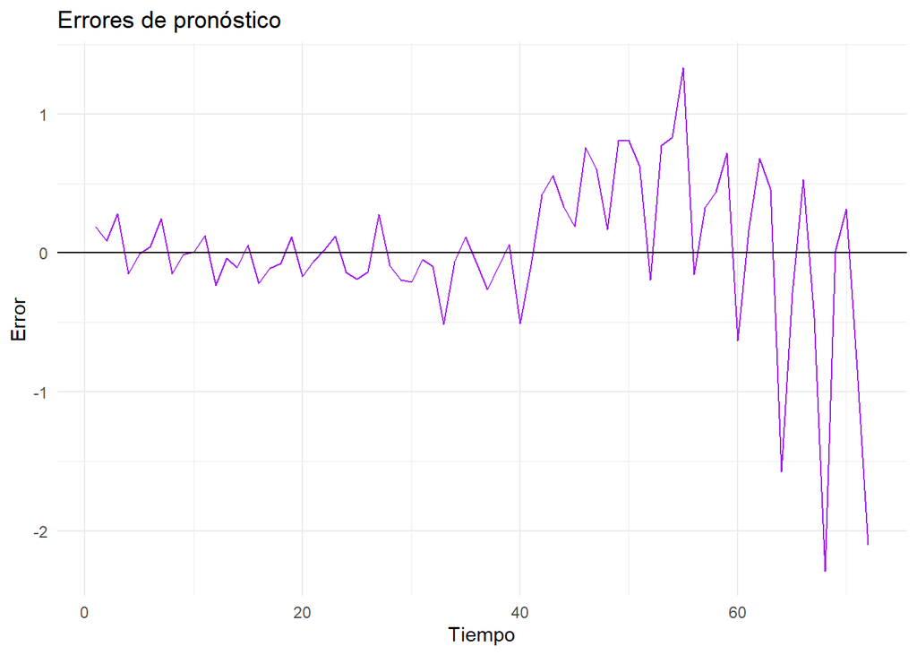

```r
resultado_errores_J$grafico_errores
```

Al inicio de la serie, hasta aproximadamente el tiempo 40, los errores son pequeños y se mantienen cerca de 0, entre aproximadamente -0.5 y 0.3. Después del tiempo 40, la amplitud de los errores aumenta considerablemente, llegando a superar 1 en la parte positiva y alcanzando valores cercanos a -2.2 hacia el final de la serie.

Esto muestra que la magnitud de los errores no se mantiene constante a lo largo del tiempo, sino que tiende a aumentar a medida que avanza la serie. Este comportamiento es coherente con la serie original, donde las oscilaciones también aumentan junto con el nivel de la serie, lo que es compatible con un patrón de crecimiento multiplicativo.

Por lo tanto, el modelo de tendencia exponencial presenta mayores dificultades para ajustar la parte final de la serie, donde los valores son más altos y las variaciones son mayores.

**Correlograma**

**Mostrar/ocultar código**

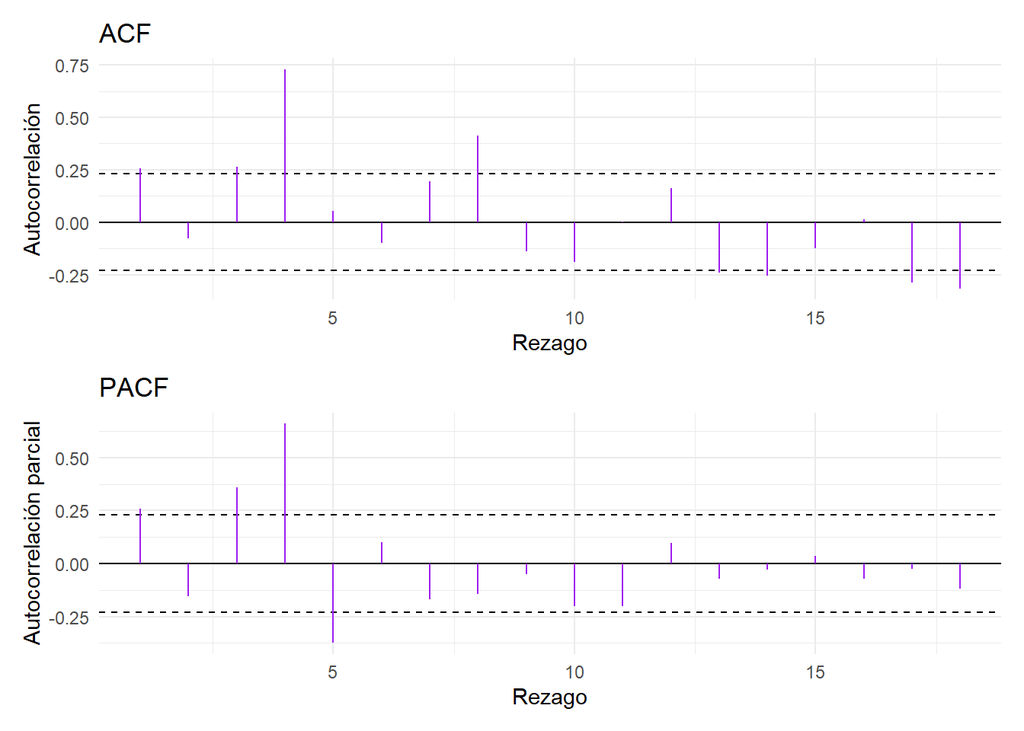

```r
resultado_errores_J$correlograma$grafico
```

En el PACF se observa un comportamiento similar. El rezago 4 presenta el valor más alto, cercano a 0.65, mientras que el rezago 5 también se encuentra ligeramente fuera de la banda en la parte negativa.

En general, la mayoría de los rezagos no presentan autocorrelaciones significativas, por lo que los errores muestran una dependencia temporal mucho menor que la serie original. Sin embargo, el pico importante en el rezago 4 es relevante porque JohnsonJohnson es una serie trimestral y cuatro períodos corresponden aproximadamente a un año. Esto sugiere que todavía podría quedar cierta dependencia asociada al comportamiento trimestral que la tendencia exponencial no logró capturar completamente.

**Residuos vs valores ajustados**

**Mostrar/ocultar código**

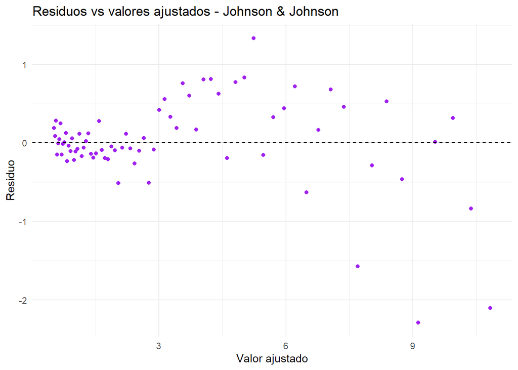

```r
datos_residuos_J <- data.frame(
  ajustado = modelo_J$yhat[posiciones_J],
  residuo = errores_J
)

ggplot2::ggplot(
  datos_residuos_J,
  ggplot2::aes(x = ajustado, y = residuo)
) +
  ggplot2::geom_point(color = "purple") +
  ggplot2::geom_hline(yintercept = 0, linetype = "dashed") +
  ggplot2::labs(
    title = "Residuos vs valores ajustados - Johnson & Johnson",
    x = "Valor ajustado",
    y = "Residuo"
  ) +
  ggplot2::theme_minimal()
```

Los residuos crecen en tamaño a medida que aumenta el valor ajustado: cuando el ajuste es bajo, los residuos están muy cerca de cero, y cuando el ajuste sube, los residuos llegan hasta -2.2 y -2.1.

Esto muestra que la varianza del error no es constante: es mucho más pequeña cuando el nivel de la serie es bajo, y más grande cuando el nivel es alto.

**Prueba t (errores)**

Prueba de Hipótesis

$$H_0: \mu_e = 0$$
$$H_1: \mu_e \neq 0$$

Estadístico de Prueba:

$$t = \frac{\bar{e}}{s_e / \sqrt{72}}$$

Distribución bajo $H_0$

$$t \sim t_{71}$$

Región de Rechazo

$$|t| > t_{0.975,\,71}$$

**Mostrar/ocultar código**

```r
cat(
  "Estadístico de prueba:", round(resultado_errores_J$t, 4), "\n",
  "Grados de libertad:", resultado_errores_J$grados_libertad_t, "\n",
  "Valor crítico:", round(
    qt(0.975, resultado_errores_J$grados_libertad_t), 4
  ), "\n",
  "Valor p:", round(resultado_errores_J$valor_p_t, 4), "\n"
)
```

```
Estadístico de prueba: 0.209
 Grados de libertad: 71
 Valor crítico: 1.9939
 Valor p: 0.8351
```

El estadístico observado es $t=0.209$, mientras que el valor crítico para un nivel de significancia del 5 % es $1.9939$. Como $|0.209|<1.9939$, no se rechaza $H_0$. Esto también es consistente con el valor p de 0.8351, que es mayor que 0.05.

Por lo tanto, no hay evidencia estadísticamente significativa de que la media de los errores sea diferente de cero. En consecuencia, no se observa un sesgo sistemático hacia la sobreestimación o la subestimación de los valores reales.

**Ljung Box (errores)**

Prueba de Hipótesis

$$H_0:\rho_1=\rho_2=\cdots=\rho_{18}=0$$
$$H_1:\text{al menos una }\rho_h\neq0$$

Estadístico de Prueba

$$Q = 72(72 + 2) \sum_{h=1}^{18} \frac{{r}_h^2}{72 - h}$$

Distribución

$$Q \sim \chi^2_{16}$$

Región de Rechazo

$$Q > \chi^2_{0.95, 16}$$

**Mostrar/ocultar código**

```r
cat(
  "Estadístico de prueba:", round(
    resultado_errores_J$ljung_box$estadistico, 4
  ), "\n",
  "Grados de libertad:", resultado_errores_J$ljung_box$grados_libertad, "\n",
  "Valor crítico:", round(
    resultado_errores_J$ljung_box$valor_critico, 4
  ), "\n",
  "Valor p:", round(
    resultado_errores_J$ljung_box$valor_p, 4
  ), "\n"
)
```

```
Estadístico de prueba: 108.5986
 Grados de libertad: 16
 Valor crítico: 26.2962
 Valor p: 0
```

Como $Q=108.60$ es mucho mayor que el valor crítico $26.2962$, se rechaza $H_0$, con un valor p menor que 0.0001. Por lo tanto, hay evidencia estadísticamente significativa de que las autocorrelaciones de los errores, consideradas conjuntamente, no son todas iguales a cero.

Este resultado es consistente con lo observado en el correlograma. Aunque solamente algunos rezagos presentan autocorrelaciones individuales fuera de las bandas, la prueba de Ljung-Box evalúa conjuntamente los rezagos y detecta evidencia de dependencia temporal en los errores.

El pico pronunciado en el rezago 4 es especialmente relevante, ya que JohnsonJohnson es una serie trimestral y cuatro períodos corresponden aproximadamente a un año. Esto sugiere que todavía puede quedar cierta dependencia asociada al comportamiento anual que la tendencia exponencial no logró capturar completamente.

**Jarque Bera**

Prueba de Hipótesis

$$H_0:\text{los errores tienen distribución normal}$$
$$H_1:\text{los errores no tienen distribución normal}$$

Distribución Bajo $H_0$:

$$JB \sim \chi^2_{2}$$

Estadístico de Prueba

$$JB = \frac{72}{6} \left( A^2 + \frac{(K - 3)^2}{4} \right)$$

Región de rechazo

$$JB>\chi^2_{0.95,2}$$

**Mostrar/ocultar código**

```r
cat(
  "Estadístico de prueba:", round(
    resultado_errores_J$jarque_bera$estadistico, 4
  ), "\n",
  "Grados de libertad:", resultado_errores_J$jarque_bera$grados_libertad, "\n",
  "Valor crítico:", round(
    resultado_errores_J$jarque_bera$valor_critico, 4
  ), "\n",
  "Valor p:", format.pval(
    resultado_errores_J$jarque_bera$valor_p,
    digits = 4
  ), "\n"
)
```

```
Estadístico de prueba: 111.5297
 Grados de libertad: 2
 Valor crítico: 5.9915
 Valor p: < 2.2e-16
```

Como JB = 111.53 es mucho mayor que el valor crítico 5.9915, se rechaza $H_0$, con un valor p menor que 2.2e-16. Hay evidencia de que los errores no siguen una distribución normal.

Esto es coherente con lo que se vio en el gráfico de errores: la variabilidad crece hacia el final de la serie (errores pequeños al inicio, mucho más grandes después), lo que rompe el supuesto de normalidad.

**Durbin Watson**

Prueba de Hipótesis:

$$H_0:\rho=0$$
$$H_1:\rho\neq0$$

Estadístico de Prueba:

$$DW=\frac{\sum_{t=2}^{72}(e_t-e_{t-1})^2} {\sum_{t=1}^{72}e_t^2}$$

**Mostrar/ocultar código**

```r
# Valores críticos de Durbin-Watson al 5%
tabla_dw <- data.frame(
  n = c(15, 20, 25, 30, 40, 50, 60, 70, 80, 90, 100),
  dL = c(1.08, 1.20, 1.29, 1.35, 1.44, 1.50, 1.55, 1.58, 1.61, 1.63, 1.65),
  dU = c(1.36, 1.41, 1.45, 1.49, 1.54, 1.59, 1.62, 1.64, 1.66, 1.68, 1.69)
)

# Número de errores
n <- length(modelo_J$parametros$residuos)

# Valores críticos aproximados
dL <- approx(tabla_dw$n, tabla_dw$dL, xout = n)$y
dU <- approx(tabla_dw$n, tabla_dw$dU, xout = n)$y

# Estadístico Durbin-Watson
DW <- modelo_J$parametros$DW

cat("n =", n, "\n",
    "DW =", round(DW, 4), "\n",
    "dL =", round(dL, 4), "\n",
    "dU =", round(dU, 4), "\n",
    "4 - dU =", round(4 - dU, 4), "\n",
    "4 - dL =", round(4 - dL, 4), "\n")
```

```
n = 72
 DW = 1.6898
 dL = 1.586
 dU = 1.644
 4 - dU = 2.356
 4 - dL = 2.414
```

Como DW=1.6898 es mayor que dU=1.644, no se rechaza $H_0$. No hay evidencia de autocorrelación de primer orden en los errores.

Este resultado es distinto al de Población australiana y Millas de pasajeros, donde sí se detectó autocorrelación positiva. Aquí, como no se rechaza la hipótesis nula, el error estándar ordinario de los coeficientes es confiable y no es necesario apoyarse solo en el robusto para interpretar los valores p

**Pruebas t sobre los coeficientes (error estándar robusto)**

Prueba de Hipótesis:

$$H_0: \beta_j = 0$$
$$H_1: \beta_j \neq 0$$
Estadístico de Prueba:

$$t = \frac{\hat\beta_j}{SE_{robusto}(\hat\beta_j)}$$
Distribución bajo $H_0$:

$$t \sim t_{n-2}$$
Región de Rechazo:

$$|t| > t_{0.975,\,n-2}$$

**Mostrar/ocultar código**

```r
tabla_coef_J <- modelo_J$parametros$coeficientes

tabla_coef_J$estimacion   <- round(tabla_coef_J$estimacion, 4)
tabla_coef_J$se_ordinario <- round(tabla_coef_J$se_ordinario, 4)
tabla_coef_J$se_robusto   <- round(tabla_coef_J$se_robusto, 4)
tabla_coef_J$t            <- round(tabla_coef_J$t, 4)
tabla_coef_J$valor_p      <- format.pval(tabla_coef_J$valor_p, digits = 4, eps = 0.0001)

tabla_coef_J
```

|  | coeficiente | estimacion | se_ordinario | se_robusto | t | valor_p |
| --- | --- | --- | --- | --- | --- | --- |
|  | a | -0.6968 | 0.0360 | 0.0426 | -16.3663 | < 1e-04 |
| t | theta | 0.0428 | 0.0009 | 0.0010 | 42.9616 | < 1e-04 |

**Mostrar/ocultar código**

```r
n_J <- length(y_estimacion_J)

cat(
  "Grados de libertad:", n_J - 2, "\n",
  "Valor crítico:", round(qt(0.975, n_J - 2), 4), "\n"
)
```

```
Grados de libertad: 70
 Valor crítico: 1.9944
```

Los dos coeficientes del modelo son estadísticamente significativos. Para el intercepto, se obtuvo (a=-0.6968), con (t=-16.37) y valor p menor que 0.0001. Para la tasa de crecimiento, se obtuvo $\theta=0.0428$, con (t=42.96) y valor p menor que 0.0001. En ambos casos, utilizando errores estándar robustos, se rechaza la hipótesis nula de que el coeficiente sea igual a cero.

El coeficiente $\theta$ es positivo y estadísticamente significativo, lo que proporciona evidencia de un crecimiento sostenido de la serie. En el modelo logarítmico, $\theta=0.0428$ corresponde aproximadamente a un crecimiento de 4.28 % por trimestre

**Gráfico Final**

**Mostrar/ocultar código**

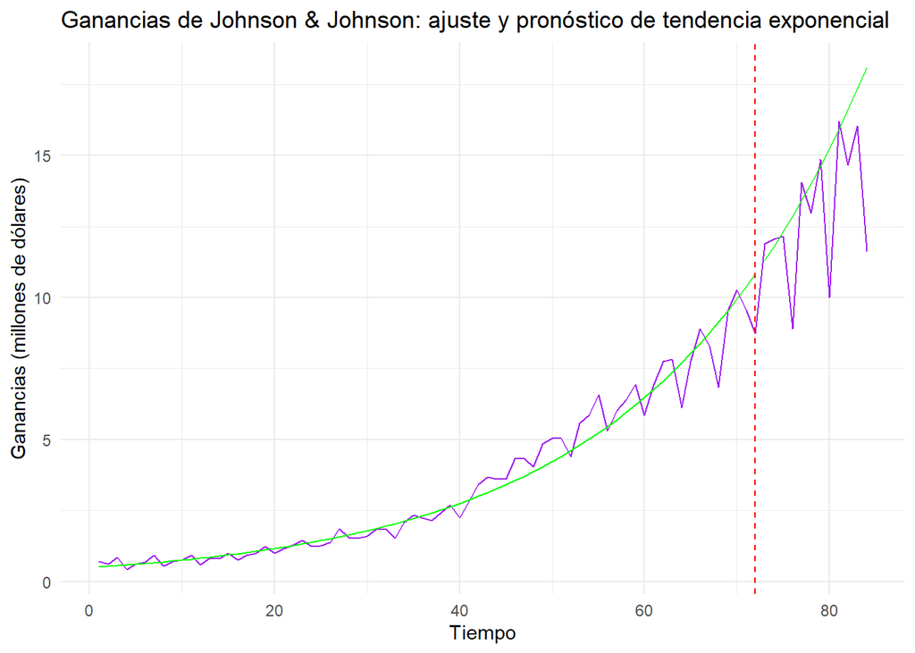

```r
ggplot2::ggplot(
  data.frame(
    tiempo = 1:T_J,
    real = datos_J$y,
    ajuste = c(modelo_J$yhat, rep(NA, h_J)),
    pronostico = c(rep(NA, T_J - h_J), pronosticos_J)
  ),
  ggplot2::aes(x = tiempo)
) +

  ggplot2::geom_line(
    ggplot2::aes(y = real),
    color = "purple"
  ) +

  ggplot2::geom_line(
    ggplot2::aes(y = ajuste),
    color = "green"
  ) +

  ggplot2::geom_line(
    ggplot2::aes(y = pronostico),
    color = "green"
  ) +

  ggplot2::geom_vline(
    xintercept = T_J - h_J,
    color = "red",
    linetype = "dashed"
  ) +

  ggplot2::labs(
    title = "Ganancias de Johnson & Johnson: ajuste y pronóstico de tendencia exponencial",
    x = "Tiempo",
    y = "Ganancias (millones de dólares)"
  ) +

  ggplot2::theme_minimal()
```

Durante el tramo de estimación, el ajuste de la tendencia exponencial sigue adecuadamente la forma general de crecimiento de la serie real. Sin embargo, no captura las oscilaciones trimestrales, ya que el modelo representa principalmente la tendencia de crecimiento de fondo.

En el tramo de validación, después de la línea roja, el pronóstico continúa aumentando de forma suave, mientras que la serie real presenta oscilaciones más marcadas, con picos y caídas importantes. Por ejemplo, hacia el final de la validación, la serie alcanza aproximadamente 16 y posteriormente disminuye hasta cerca de 11.7. El pronóstico se mantiene alrededor del nivel central de estas oscilaciones, pero no logra seguir sus cambios trimestrales.

Este comportamiento muestra una limitación del método: la tendencia exponencial logra representar el crecimiento general de la serie, pero no incorpora la variabilidad estacional de corto plazo. Esto es consistente con el pico observado en el rezago 4 del correlograma de los errores y con el aumento de la magnitud de los errores hacia el final de la serie.

**Conclusión**

La serie de ganancias de Johnson & Johnson se ajustó mediante una tendencia exponencial, obteniendo $a=-0.6968$ y $\theta=0.0428$, ambos estadísticamente significativos con valores p menores que 0.0001. El parámetro de tendencia positivo representa un crecimiento porcentual sostenido de la serie. En el período de validación, el modelo obtuvo un MSE de $7.74$, un MAD de $1.84$, un MAPE de $16.54\%$ y un MASE de $4.1401$, mientras que el método ingenuo alcanzó $22.53$, $4.22$, $30.46\%$ y $9.4584$, respectivamente. Por tanto, aunque el error sigue siendo considerable, la tendencia exponencial consiguió una reducción importante frente al referente.

La tendencia exponencial puede ser una referencia para analistas financieros o responsables de planeación de resultados que estén interesados principalmente en la trayectoria de crecimiento de las ganancias. Puede utilizarse para horizontes de hasta 12 períodos como aproximación del crecimiento general, pero no debería emplearse de forma aislada para planificar resultados trimestrales, debido a que no incorpora la estacionalidad anual detectada en el rezago 4. Para decisiones financieras donde esa variación sea relevante, sería necesario complementar el pronóstico con un componente estacional.

### 3.8 Uso de Internet

**Descripción de la serie**

**Mostrar/ocultar código**

```r
propiedades_W <- data.frame(
  Métrica    = c("Longitud de la serie (n)",
                 "Fecha/periodo de inicio",
                 "Fecha/periodo de fin",
                 "Frecuencia observada"),
  Valor      = c(length(datos_W$y),
                 start(WWWusage)[1],
                 end(WWWusage)[1],
                 frequency(WWWusage)),
  Descripción = c("Número total de observaciones",
                  "Primer periodo registrado en la serie",
                  "Último periodo registrado en la serie",
                  "Frecuencia de medición (1 dato/minuto)"),
  stringsAsFactors = FALSE
)

propiedades_W
```

| Métrica | Valor | Descripción |
| --- | --- | --- |
| Longitud de la serie (n) | 100 | Número total de observaciones |
| Fecha/periodo de inicio | 1 | Primer periodo registrado en la serie |
| Fecha/periodo de fin | 100 | Último periodo registrado en la serie |
| Frecuencia observada | 1 | Frecuencia de medición (1 dato/minuto) |

La serie está compuesta por 100 observaciones, correspondientes a 100 periodos consecutivos. El primer periodo registrado es el 1 y el último es el 100. Además, la frecuencia de observación es de un dato por minuto, por lo que se cuenta con una medición cada minuto.

**Exploración de la serie**

**Gráficos**

**Mostrar/ocultar código**

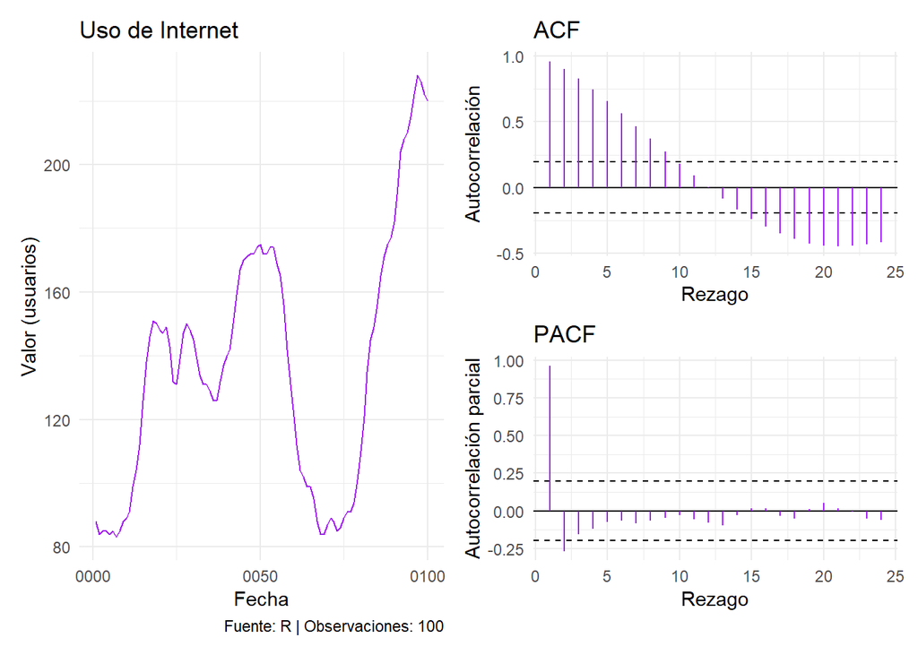

```r
datos_W <- leer_serie(
  WWWusage,
  fuente = "R",
  unidad = "usuarios"
)

grafico_W <- graficar_serie(
  datos_W,
  "Uso de Internet"
)

cor_W <- correlograma(
  datos_W$y
)

panel_W <- panel_diagnostico(
  grafico_W,
  cor_W
)

print(panel_W)
```

La serie de uso de Internet presenta una tendencia, no es estacionaria, ya que su nivel cambia con el tiempo. No se observa una estacionalidad clara.

**Contraste individual de los \(r_h\)**

Prueba de Hipótesis

$$H_0:\rho_h=0$$
$$H_1:\rho_h\neq0$$

Estadístico de Prueba:

$$Z_h=\frac{r_h}{1/\sqrt{100}}$$

Distribución bajo $H_0$:

$$Z_h\sim N(0,1)$$

Región de rechazo al 5 %:

$$|Z_h|>1.96$$

**Mostrar/ocultar código**

```r
#Contaste individual
r_W <- cor_W$acf

T_W <- length(datos_W$y)

z_W <- r_W * sqrt(T_W)

valor_p_W <- 2 * pnorm(-abs(z_W))

valor_critico_W <- qnorm(0.975)
```

**Mostrar/ocultar código**

```r
tabla_acf_W <- data.frame(
  rezago = 1:length(r_W),
  r_h = r_W,
  estadistico = z_W,
  valor_p = valor_p_W,
  significativo = abs(z_W) > valor_critico_W
)

tabla_acf_W$r_h         <- round(tabla_acf_W$r_h, 4)
tabla_acf_W$estadistico <- round(tabla_acf_W$estadistico, 4)
tabla_acf_W$valor_p     <- format.pval(tabla_acf_W$valor_p, digits = 4, eps = 0.0001)
tabla_acf_W$significativo <- ifelse(tabla_acf_W$significativo, "Sí", "No")

tabla_acf_W
```

| rezago | r_h | estadistico | valor_p | significativo |
| --- | --- | --- | --- | --- |
| 1 | 0.9602 | 9.6018 | < 1e-04 | Sí |
| 2 | 0.9011 | 9.0114 | < 1e-04 | Sí |
| 3 | 0.8287 | 8.2875 | < 1e-04 | Sí |
| 4 | 0.7460 | 7.4599 | < 1e-04 | Sí |
| 5 | 0.6572 | 6.5724 | < 1e-04 | Sí |
| 6 | 0.5647 | 5.6472 | < 1e-04 | Sí |
| 7 | 0.4686 | 4.6856 | < 1e-04 | Sí |
| 8 | 0.3709 | 3.7088 | 0.0002083 | Sí |
| 9 | 0.2742 | 2.7418 | 0.0061104 | Sí |
| 10 | 0.1809 | 1.8085 | 0.0705227 | No |

[output cut: 14 more lines]

La prueba busca determinar, para cada rezago, si existe evidencia de autocorrelación o si el valor observado podría deberse al azar.

Los rezagos 1 al 9 son significativos y presentan autocorrelaciones positivas altas, que disminuyen de 0.96 a 0.27. Esto indica una fuerte dependencia temporal: los valores cercanos en el tiempo tienden a moverse en la misma dirección.

Entre los rezagos 10 y 14 no se encuentra evidencia estadísticamente significativa de autocorrelación. En este intervalo, la autocorrelación pasa de valores positivos a negativos.

A partir del rezago 15 y hasta el 24, las autocorrelaciones vuelven a ser significativas, pero ahora son negativas, con valores entre -0.24 y -0.45. Esto indica que, a esas separaciones temporales, valores altos tienden a asociarse con valores bajos y viceversa.

En los rezagos analizados no se observa un patrón periódico que se repita de manera regular, por lo que no hay evidencia clara de estacionalidad a partir de estas autocorrelaciones. En conjunto, los resultados muestran una dependencia temporal importante, especialmente en los primeros rezagos.

**Ljung Box**

Prueba Hipótesis

$$H_0:\rho_1=\rho_2=\cdots=\rho_{24}=0$$
$$H_1:\text{al menos una }\rho_h\neq0$$

Estadístico de Prueba

$$Q = 100(100 + 2) \sum_{h=1}^{24} \frac{{r}_h^2}{100 - h}$$

Distribución

$$Q \sim \chi^2_{24}$$

Región de Rechazo

$$Q > \chi^2_{0.95, 24}$$

**Mostrar/ocultar código**

```r
#Lung box
resultado_lb_W <- ljung_box(
  r = cor_W$acf,
  T = length(datos_W$y),
  m = length(cor_W$acf),
  p = 0
)

cat(
  "Uso de Internet → Q =", round(resultado_lb_W$estadistico, 4),
  "| gl =", resultado_lb_W$grados_libertad,
  "| valor crítico =", round(resultado_lb_W$valor_critico, 4),
  "| p-valor =", round(resultado_lb_W$valor_p, 4), "\n"
)
```

```
Uso de Internet → Q = 647.7985 | gl = 24 | valor crítico = 36.415 | p-valor = 0
```

Como $Q=647.80$ es mucho mayor que el valor crítico $36.415$, se rechaza $H_0$, con un valor p menor que 0.0001. Hay evidencia de que las autocorrelaciones, consideradas conjuntamente hasta el rezago analizado, no son todas iguales a cero. Por lo tanto, la serie no es ruido blanco y presenta una fuerte dependencia temporal, coherente con lo observado en los contrastes individuales.

**Estimación y Validación**

**Partición de la serie**

**Mostrar/ocultar código**

```r
#Paricion
h_W <- min(
  12,
  floor(0.2 * T_W)
)

y_estimacion_W <- datos_W$y[1:(T_W - h_W)]

y_validacion_W <- datos_W$y[(T_W - h_W + 1):T_W]

cat(
  "Uso de Internet → Estimación =", length(y_estimacion_W),
  "| Validación =", length(y_validacion_W), "\n"
)
```

```
Uso de Internet → Estimación = 88 | Validación = 12
```

La serie de Uso de Internet tiene 100 observaciones en total. Se usaron 88 para estimar el modelo y las últimas 12 para validarlo

**Optimización de alpha y beta**

**Mostrar/ocultar código**

```r
# Optimización de la ventana de la media móvil
resultado_opt_W <- optimizar(
  y = y_estimacion_W,
  metodo = "holt",
  rejilla = seq(0.1, 0.9, by = 0.1)
)
```

**Mostrar/ocultar código**

```r
resultado_opt_W$rejilla
```

| alpha | beta | MSE |
| --- | --- | --- |
| 0.1 | 0.1 | 878.51560 |
| 0.2 | 0.1 | 401.04280 |
| 0.3 | 0.1 | 208.72822 |
| 0.4 | 0.1 | 127.93499 |
| 0.5 | 0.1 | 87.47106 |
| 0.6 | 0.1 | 64.21704 |
| 0.7 | 0.1 | 49.54144 |
| 0.8 | 0.1 | 39.64187 |
| 0.9 | 0.1 | 32.61886 |
| 0.1 | 0.2 | 930.68458 |

[output cut: 71 more lines]

**Mostrar/ocultar código**

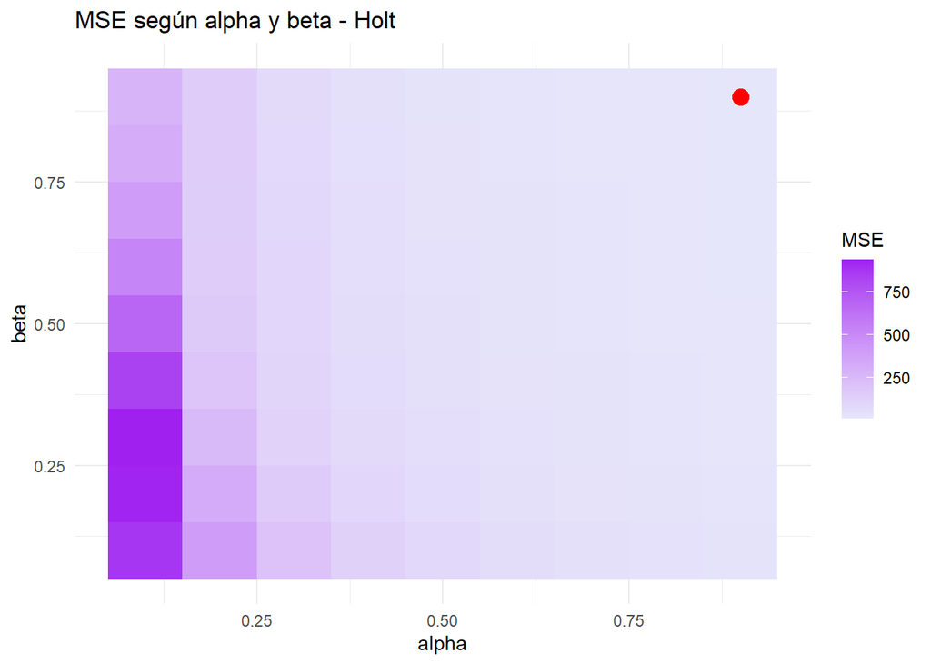

```r
grafico_opt_W <- graficar_holt(
  resultado = resultado_opt_W
)

grafico_opt_W
```

El menor MSE se obtiene con $\alpha=0.9$ y $\beta=0.9$, con un valor de 15.10. Dentro de la rejilla evaluada, se observa que los valores más altos de $\alpha$ y $\beta$ producen menores errores.

Cuando $\alpha$ es bajo, por ejemplo 0.1, el MSE es mucho mayor independientemente del valor de $\beta$, llegando hasta 939.50. Esto puede explicarse porque un $\alpha$ bajo hace que el nivel del modelo se actualice más lentamente y dé mayor peso a información pasada, mientras que la serie presenta cambios rápidos.

Sin embargo, el óptimo se encuentra en el borde superior de la rejilla, ya que 0.9 es el mayor valor evaluado. Por esta razón, no se puede asegurar que este sea el mínimo global y sería necesario evaluar valores más cercanos a 1 para comprobarlo.

Finalmente, los valores altos de $\alpha$ y $\beta$ indican que el modelo se adapta rápidamente a las observaciones más recientes, tanto en la estimación del nivel como de la tendencia.

**Holt lineal**

**Mostrar/ocultar código**

```r
modelo_W <- ajustar_holt(
  y_estimacion_W,
  resultado_opt_W$optimo$alpha,
  resultado_opt_W$optimo$beta
)

pronosticos_W <- modelo_W$pronosticar(h_W)

cat(
  "Horizonte de validación (h):", h_W, "\n",
  "Alpha óptimo:", resultado_opt_W$optimo$alpha, "\n",
  "Beta óptimo:", resultado_opt_W$optimo$beta, "\n",
  "Pronósticos:", round(pronosticos_W, 4), "\n"
)
```

```
Horizonte de validación (h): 12
 Alpha óptimo: 0.9
 Beta óptimo: 0.9
 Pronósticos: 179.6339 183.9724 188.3109 192.6494 196.9879 201.3263 205.6648 210.0033 214.3418 218.6803 223.0188 227.3573
```

El pronóstico no es plano, tiene pendiente: sube de 179.63 (h=1) hasta 227.36 (h=12), con un incremento fijo de 4.34 en cada paso. Esto pasa porque Holt guarda un nivel y una tendencia, y esa tendencia se repite igual durante todo el horizonte de validación.

**Medidas de error**

**Mostrar/ocultar código**

```r
posiciones_W <- which(!is.na(modelo_W$yhat))

medidas_estimacion_W <- medidas(
  y = y_estimacion_W[posiciones_W],
  yhat = modelo_W$yhat[posiciones_W]
)

medidas_validacion_W <- medidas(
  y = y_validacion_W,
  yhat = pronosticos_W
)
```

**Mostrar/ocultar código**

```r
#Ingenuo
pronosticos_ingenuo_W <- rep(
  y_estimacion_W[length(y_estimacion_W)],
  h_W
)

medidas_ingenuo_W <- medidas(
  y = y_validacion_W,
  yhat = pronosticos_ingenuo_W
)
```

**Mostrar/ocultar código**

```r
#Escala MASE
escala_mase_W <- mean(
  abs(
    y_estimacion_W[2:length(y_estimacion_W)] -
    y_estimacion_W[1:(length(y_estimacion_W) - 1)]
  )
)

mase_estim_W <- medidas_estimacion_W$MAD / escala_mase_W
mase_valid_W <- medidas_validacion_W$MAD / escala_mase_W
mase_ingenuo_W <- medidas_ingenuo_W$MAD / escala_mase_W
```

**Mostrar/ocultar código**

```r
tabla_medidas_W <- data.frame(
  Tramo = c("Estimación", "Validación", "Validación"),
  Método = c("Holt lineal", "Holt lineal", "Ingenuo"),
  MSE = c(
    medidas_estimacion_W$MSE,
    medidas_validacion_W$MSE,
    medidas_ingenuo_W$MSE
  ),
  MAD = c(
    medidas_estimacion_W$MAD,
    medidas_validacion_W$MAD,
    medidas_ingenuo_W$MAD
  ),
  MAPE = c(
    medidas_estimacion_W$MAPE,
    medidas_validacion_W$MAPE,
    medidas_ingenuo_W$MAPE
  ),
  MASE = c(
    mase_estim_W,
    mase_valid_W,
    mase_ingenuo_W
  )
)

tabla_medidas_W
```

| Tramo | Método | MSE | MAD | MAPE | MASE |
| --- | --- | --- | --- | --- | --- |
| Estimación | Holt lineal | 15.09669 | 3.185411 | 2.599826 | 0.7161001 |
| Validación | Holt lineal | 73.70909 | 7.584803 | 3.564022 | 1.7051107 |
| Validación | Ingenuo | 1415.41667 | 33.916667 | 15.688649 | 7.6246770 |

En estimación, Holt lineal tuvo un MSE de 15.10, un MAD de 3.19, un MAPE de 2.60% y un MASE de 0.7161. Estos valores indican que el modelo tuvo un ajuste relativamente bueno sobre los datos utilizados para la estimación.

En validación, el MSE aumentó a 73.71, el MAD a 7.58, el MAPE a 3.56% y el MASE a 1.7051. Este aumento es normal al pasar de evaluar el ajuste sobre datos conocidos a evaluar pronósticos sobre datos nuevos.

Al comparar con el ingenuo en el mismo tramo de validación, Holt lineal presenta menores errores en todas las medidas. Por ejemplo, el MSE fue de 73.71 frente a 1415.42 y el MASE de 1.71 frente a 7.62. Por lo tanto, Holt lineal supera al ingenuo en esta validación. Este resultado es coherente con la presencia de una tendencia en la serie, que Holt puede incorporar mediante su componente de tendencia, mientras que el método ingenuo no la modela.

**Validación de los errores**

**Mostrar/ocultar código**

```r
posiciones_W <- which(!is.na(modelo_W$yhat))

errores_W <- y_estimacion_W[posiciones_W] - modelo_W$yhat[posiciones_W]

resultado_errores_W <- validar_errores(
  e = errores_W,
  m = NULL,
  p = 2
)
```

**Gráfico**

**Mostrar/ocultar código**

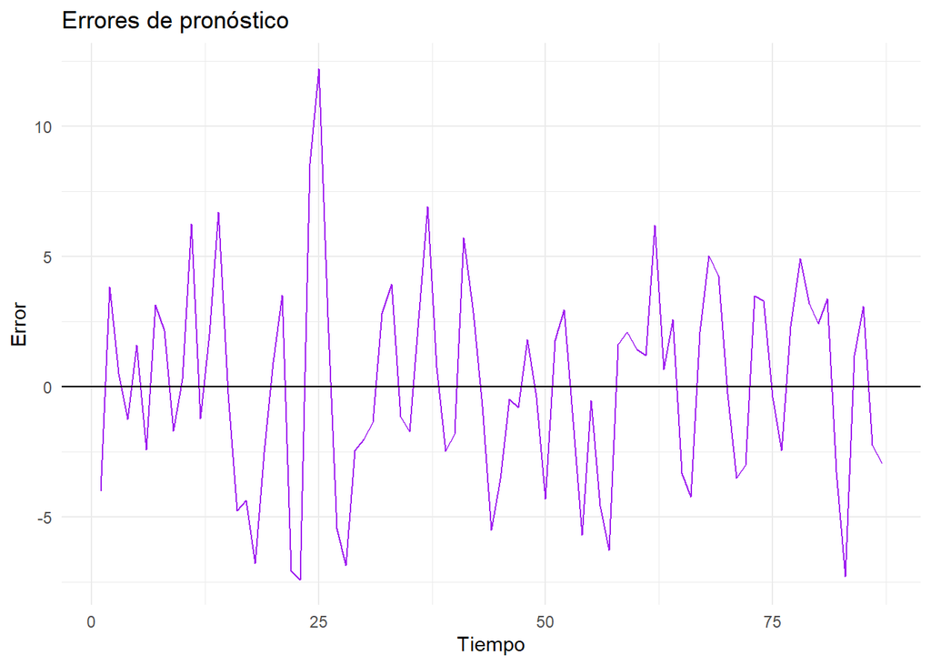

```r
resultado_errores_W$grafico_errores
```

Los errores oscilan alrededor de 0, subiendo y bajando de forma irregular, sin observarse un ciclo fijo que se repita. Esto es diferente a lo observado en la serie original, donde la autocorrelación disminuía lentamente y posteriormente se volvía negativa.

Se observa un pico grande cerca del tiempo 25, donde el error alcanza aproximadamente 12.5, mientras que la mayoría de los errores se encuentran entre -7 y 7. Este punto podría corresponder a una observación atípica y conviene tenerlo en cuenta al interpretar los resultados.

En general, los errores presentan un comportamiento más irregular y cercano al de un ruido que la serie original. Sin embargo, esta apreciación visual debe complementarse con el correlograma y las pruebas de media cero, Ljung–Box y normalidad para determinar si los errores cumplen las condiciones esperadas.

**Correlograma**

**Mostrar/ocultar código**

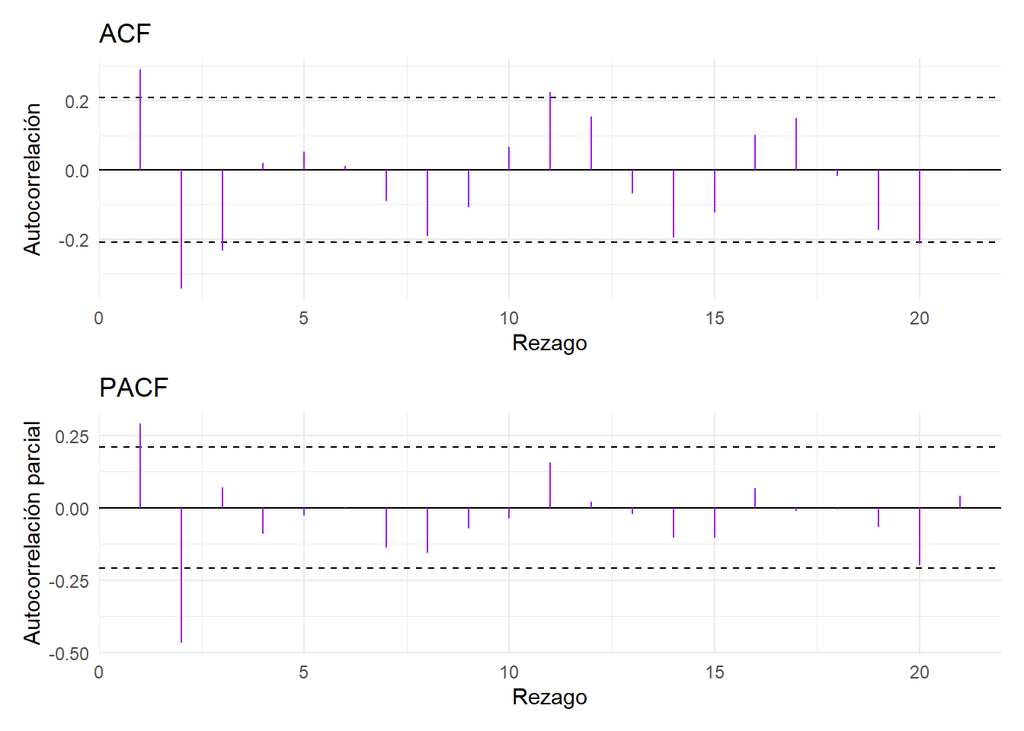

```r
resultado_errores_W$correlograma$grafico
```

En el PACF se observa un comportamiento similar, aunque el rezago 2 es el que sobresale claramente de la banda, con un valor cercano a -0.45.

En comparación con la serie original, que presentaba autocorrelaciones fuertes en muchos rezagos, los errores muestran una dependencia temporal mucho menor. Esto indica que el modelo de Holt lineal logró capturar una parte importante de la estructura temporal de la serie. Sin embargo, la presencia de algunos rezagos significativos indica que no se puede afirmar únicamente con estos gráficos que los errores sean completamente ruido blanco.

**Prueba t**

Prueba de Hipótesis

$$H_0: \mu_e = 0$$
$$H_1: \mu_e \neq 0$$

Estadístico de Prueba:

$$t = \frac{\bar{e}}{s_e / \sqrt{87}}$$

Distribución bajo $H_0$

$$t \sim t_{n-1}$$

Región de Rechazo

$$|t| > t_{0.975,\,86}$$

**Mostrar/ocultar código**

```r
cat(
  "Estadístico de prueba:", round(resultado_errores_W$t, 4), "\n",
  "Grados de libertad:", resultado_errores_W$grados_libertad_t, "\n",
  "Valor crítico:", round(
    qt(0.975, resultado_errores_W$grados_libertad_t), 4
  ), "\n",
  "Valor p:", round(resultado_errores_W$valor_p_t, 4), "\n"
)
```

```
Estadístico de prueba: 0.147
 Grados de libertad: 86
 Valor crítico: 1.9879
 Valor p: 0.8835
```

La prueba t busca determinar si la media de los errores es igual a cero o si existe evidencia de un sesgo sistemático.

Como el valor absoluto del estadístico (t=0.147) es menor que el valor crítico $1.9879$, no se rechaza $H_0$. Esto también es consistente con el valor p de 0.8835, que es mayor que 0.05.

Por lo tanto, no hay evidencia estadísticamente significativa de que la media de los errores sea diferente de cero. En consecuencia, no se observa un sesgo sistemático hacia la sobreestimación o la subestimación de los valores reales.

**Ljung Box (errores)**

Prueba de Hipótesis

$$H_0:\rho_1=\rho_2=\cdots=\rho_{21}=0$$
$$H_1:\text{al menos una }\rho_h\neq0$$

Estadístico de Prueba

$$Q = T(T + 2) \sum_{h=1}^{21} \frac{{r}_h^2}{87 - h}$$

Distribución

$$Q \sim \chi^2_{19}$$

Región de Rechazo

$$Q > \chi^2_{0.95, 19}$$

**Mostrar/ocultar código**

```r
cat(
  "Estadístico de prueba:", round(
    resultado_errores_W$ljung_box$estadistico, 4
  ), "\n",
  "Grados de libertad:", resultado_errores_W$ljung_box$grados_libertad, "\n",
  "Valor crítico:", round(
    resultado_errores_W$ljung_box$valor_critico, 4
  ), "\n",
  "Valor p:", round(
    resultado_errores_W$ljung_box$valor_p, 4
  ), "\n"
)
```

```
Estadístico de prueba: 55.8048
 Grados de libertad: 19
 Valor crítico: 30.1435
 Valor p: 0
```

Como (Q=55.80) es mayor que el valor crítico (30.1435), se rechaza ($H_0$), con un valor p menor que 0.0001. Por lo tanto, hay evidencia estadísticamente significativa de que las autocorrelaciones de los errores, consideradas conjuntamente, no son todas iguales a cero.

**Jarque Bera**

Prueba de Hipótesis

$$H_0:\text{los errores tienen distribución normal}$$
$$H_1:\text{los errores no tienen distribución normal}$$

Distribución Bajo $H_0$:

$$JB \sim \chi^2_{2}$$

Estadístico de Prueba

$$JB = \frac{87}{6} \left( A^2 + \frac{(K - 3)^2}{4} \right)$$

Región de rechazo

$$JB>\chi^2_{0.95,2}$$

**Mostrar/ocultar código**

```r
cat(
  "Estadístico de prueba:", round(
    resultado_errores_W$jarque_bera$estadistico, 4
  ), "\n",
  "Grados de libertad:", resultado_errores_W$jarque_bera$grados_libertad, "\n",
  "Valor crítico:", round(
    resultado_errores_W$jarque_bera$valor_critico, 4
  ), "\n",
  "Valor p:", format.pval(
    resultado_errores_W$jarque_bera$valor_p,
    digits = 4
  ), "\n"
)
```

```
Estadístico de prueba: 0.623
 Grados de libertad: 2
 Valor crítico: 5.9915
 Valor p: 0.7323
```

Como JB = 0.623 es menor que el valor crítico 5.9915, no se rechaza $H_0$, con un valor p de 0.7323. No hay evidencia de que los errores se alejen de la normalidad.

**Durbin Watson**

Prueba de Hipótesis:

$$H_0:\rho=0$$
$$H_1:\rho\neq0$$

Estadístico de Prueba:

$$DW=\frac{\sum_{t=2}^{87}(e_t-e_{t-1})^2} {\sum_{t=1}^{87}e_t^2}$$

**Mostrar/ocultar código**

```r
cat(
  "Estadístico de prueba:", round(
    resultado_errores_W$durbin_watson$estadistico, 4
  ), "\n",
  "Grados de libertad: no aplica\n",
  "Valor crítico: no calculado\n",
  "Valor p: no calculado\n"
)
```

```
Estadístico de prueba: 1.3978
 Grados de libertad: no aplica
 Valor crítico: no calculado
 Valor p: no calculado
```

El estadístico de Durbin-Watson es (DW=1.3978). Como este valor está por debajo de 2, sugiere la presencia de autocorrelación positiva entre errores consecutivos. Sin embargo, no es un valor cercano a 0, por lo que la autocorrelación positiva no parece ser extremadamente fuerte.

Este resultado es coherente con la prueba de Ljung-Box, que encontró evidencia de dependencia temporal conjunta en los errores. Por lo tanto, aunque el correlograma mostró pocas autocorrelaciones individuales significativas, el valor de Durbin-Watson sugiere que todavía existe cierta dependencia entre errores consecutivos.

**Gráfico Final**

**Mostrar/ocultar código**

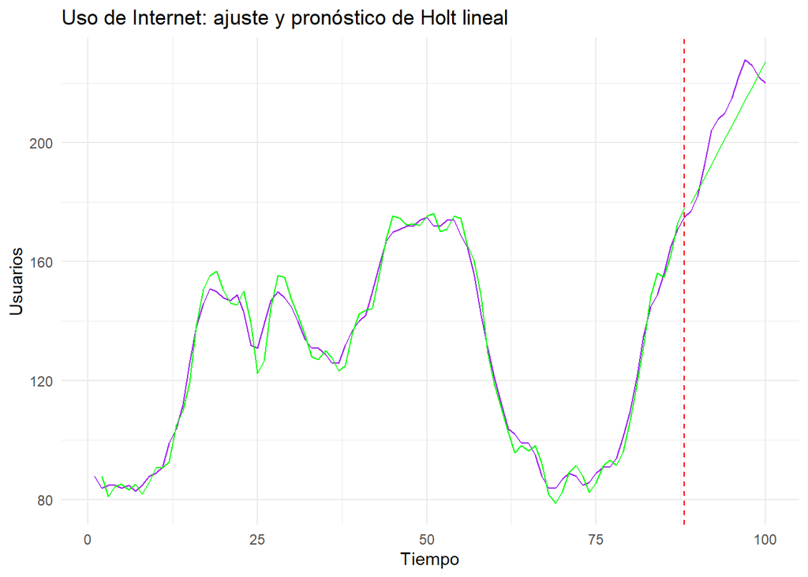

```r
ggplot2::ggplot(
  data.frame(
    tiempo = 1:T_W,
    real = datos_W$y,
    ajuste = c(modelo_W$yhat, rep(NA, h_W)),
    pronostico = c(rep(NA, T_W - h_W), pronosticos_W)
  ),
  ggplot2::aes(x = tiempo)
) +

  ggplot2::geom_line(
    ggplot2::aes(y = real),
    color = "purple"
  ) +

  ggplot2::geom_line(
    ggplot2::aes(y = ajuste),
    color = "green"
  ) +

  ggplot2::geom_line(
    ggplot2::aes(y = pronostico),
    color = "green"
  ) +

  ggplot2::geom_vline(
    xintercept = T_W - h_W,
    color = "red",
    linetype = "dashed"
  ) +

  ggplot2::labs(
    title = "Uso de Internet: ajuste y pronóstico de Holt lineal",
    x = "Tiempo",
    y = "Usuarios"
  ) +

  ggplot2::theme_minimal()
```

Durante el tramo de estimación, antes de la línea punteada, el ajuste de Holt (verde) sigue de cerca a los datos reales (morado), incluyendo varios de los cambios bruscos observados entre los tiempos 15 y 30. Esto es consistente con el bajo MSE obtenido en estimación, de 15.10.

En el tramo de validación, la serie real continúa aumentando con fuerza hasta valores cercanos a 230, mientras que el pronóstico también presenta una tendencia creciente, pero de manera más suave y constante. Como consecuencia, el pronóstico queda por debajo de los valores reales durante gran parte de este tramo.

Esto muestra una limitación del método: Holt proyecta hacia el futuro la tendencia estimada al final del periodo de estimación, manteniendo una pendiente determinada por el modelo. Por ello, no puede anticipar una aceleración del crecimiento que no estaba presente en la información utilizada para ajustar el modelo.

A pesar de esta diferencia, Holt logra incorporar la tendencia creciente de la serie en sus pronósticos, mientras que el método ingenuo habría mantenido constante el último valor observado.

**Conclusión**

Los errores no presentan evidencia de sesgo en su media, ya que la prueba t obtuvo (p=0.8835). Sin embargo, el Ljung-Box produjo (Q=55.80), con (p<0.0001), mientras que el Durbin-Watson fue (1.3978). Esto indica que, aunque Holt reduce considerablemente los errores frente al ingenuo, todavía queda dependencia temporal que el modelo no consigue explicar completamente.

Holt lineal puede ser útil para operadores de telecomunicaciones y administradores de infraestructura de Internet que necesiten anticipar la demanda de usuarios y planificar capacidad en el corto plazo. Un horizonte de hasta 12 períodos constituye una referencia razonable, pero debe revisarse periódicamente: el modelo extrapola la tendencia observada al final de la estimación y puede perder precisión cuando la velocidad de crecimiento cambia. En este caso, el MSE pasó de (15.10) en estimación a (73.71) en validación, mostrando esa pérdida de precisión fuera de muestra.

### 3.9 Contraejemplo — Población Australiana con Media Móvil

**Descripción de la serie**

Se reutiliza `datos_austres`, `cor_austres`, `tabla_acf_austres` y el resultado de Ljung-Box de la serie ya calculados en el ejemplo de tendencia lineal, porque son propiedades de la serie, no del método. No es necesario repetirlos.

**Estimación y Validación**

**Partición de la serie**

**Mostrar/ocultar código**

```r
# Se reutiliza la misma partición del ejemplo de tendencia lineal
h_austres_mm <- h_austres

y_estimacion_austres_mm <- y_estimacion_austres
y_validacion_austres_mm <- y_validacion_austres

cat(
  "Población australiana (contraejemplo) → Estimación =", length(y_estimacion_austres_mm),
  "| Validación =", length(y_validacion_austres_mm), "\n"
)
```

```
Población australiana (contraejemplo) → Estimación = 77 | Validación = 12
```

**Optimización de k**

**Mostrar/ocultar código**

```r
resultado_opt_austres_mm <- optimizar(
  y = y_estimacion_austres_mm,
  metodo = "mm",
  rejilla = 2:12
)

resultado_opt_austres_mm$rejilla
```

| k | MSE |
| --- | --- |
| 2 | 6555.864 |
| 3 | 11541.706 |
| 4 | 17916.472 |
| 5 | 25704.343 |
| 6 | 34895.834 |
| 7 | 45426.306 |
| 8 | 57303.470 |
| 9 | 70536.506 |
| 10 | 85102.450 |
| 11 | 100846.616 |

[output cut: 1 more lines]

**Mostrar/ocultar código**

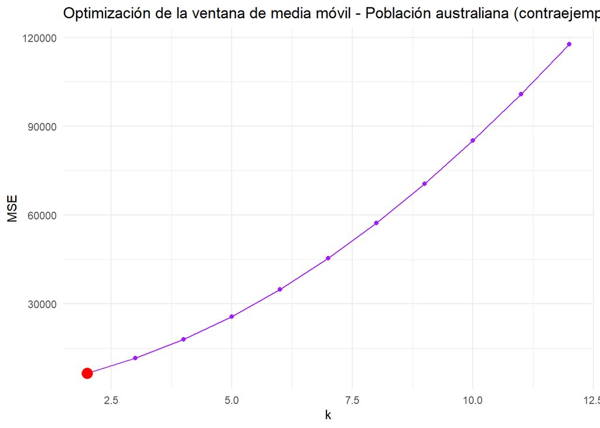

```r
grafico_opt_austres_mm <- graficar_optimizacion(
  resultado = resultado_opt_austres_mm,
  parametro = "k",
  titulo = "Optimización de la ventana de media móvil - Población australiana (contraejemplo)"
)

grafico_opt_austres_mm
```

El MSE sube sin parar mientras k crece: con k=2 da 6555.86, y con k=11 ya llega a 100846.62. El mejor valor termina siendo el más pequeño posible, k=2, porque en una serie que crece todo el tiempo, entre más datos viejos se promedien, peor queda el ajuste.

**Media móvil**

**Mostrar/ocultar código**

```r
modelo_austres_mm <- ajustar_mm(
  y = y_estimacion_austres_mm,
  k = resultado_opt_austres_mm$optimo$k
)

pronosticos_austres_mm <- modelo_austres_mm$pronosticar(h_austres_mm)

cat(
  "Horizonte de validación (h):", h_austres_mm, "\n",
  "k óptimo:", resultado_opt_austres_mm$optimo$k, "\n",
  "Pronóstico constante:", round(pronosticos_austres_mm[1], 4), "\n"
)
```

```
Horizonte de validación (h): 12
 k óptimo: 2
 Pronóstico constante: 17055.85
```

Con k=2, el pronóstico es un solo valor fijo: 17055.85, repetido en los 12 periodos de validación. Es el promedio de los dos últimos datos de estimación

**Medidas de error**

**Mostrar/ocultar código**

```r
#Posiciones
posiciones_austres_mm <- which(!is.na(modelo_austres_mm$yhat))

medidas_estimacion_austres_mm <- medidas(
  y = y_estimacion_austres_mm[posiciones_austres_mm],
  yhat = modelo_austres_mm$yhat[posiciones_austres_mm]
)

medidas_validacion_austres_mm <- medidas(
  y = y_validacion_austres_mm,
  yhat = pronosticos_austres_mm
)
```

**Mostrar/ocultar código**

```r
#Referente ingenuo
pronosticos_ingenuo_austres_mm <- rep(
  y_estimacion_austres_mm[length(y_estimacion_austres_mm)],
  h_austres_mm
)

medidas_ingenuo_austres_mm <- medidas(
  y = y_validacion_austres_mm,
  yhat = pronosticos_ingenuo_austres_mm
)
```

**Mostrar/ocultar código**

```r
#Escala MASE
escala_mase_austres_mm <- mean(
  abs(
    y_estimacion_austres_mm[2:length(y_estimacion_austres_mm)] -
    y_estimacion_austres_mm[1:(length(y_estimacion_austres_mm) - 1)]
  )
)

mase_estim_austres_mm <- medidas_estimacion_austres_mm$MAD / escala_mase_austres_mm
mase_valid_austres_mm <- medidas_validacion_austres_mm$MAD / escala_mase_austres_mm
mase_ingenuo_austres_mm <- medidas_ingenuo_austres_mm$MAD / escala_mase_austres_mm
```

**Mostrar/ocultar código**

```r
#Tabla de las medidas
tabla_medidas_austres_mm <- data.frame(
  Tramo = c("Estimación", "Validación", "Validación"),
  Método = c("Media móvil", "Media móvil", "Ingenuo"),
  MSE = c(
    medidas_estimacion_austres_mm$MSE,
    medidas_validacion_austres_mm$MSE,
    medidas_ingenuo_austres_mm$MSE
  ),
  MAD = c(
    medidas_estimacion_austres_mm$MAD,
    medidas_validacion_austres_mm$MAD,
    medidas_ingenuo_austres_mm$MAD
  ),
  MAPE = c(
    medidas_estimacion_austres_mm$MAPE,
    medidas_validacion_austres_mm$MAPE,
    medidas_ingenuo_austres_mm$MAPE
  ),
  MASE = c(
    mase_estim_austres_mm,
    mase_valid_austres_mm,
    mase_ingenuo_austres_mm
  )
)

tabla_medidas_austres_mm
```

| Tramo | Método | MSE | MAD | MAPE | MASE |
| --- | --- | --- | --- | --- | --- |
| Estimación | Media móvil | 6555.864 | 79.12533 | 0.5258811 | 1.496609 |
| Validación | Media móvil | 152910.656 | 351.59167 | 2.0102828 | 6.650150 |
| Validación | Ingenuo | 133004.791 | 322.04167 | 1.8405114 | 6.091229 |

En estimación, el error es bajo (MSE=6555.86, MAPE=0.53%), pero ya en validación se dispara: MSE=152910.66, MAD=351.59, MAPE=2.01% y MASE=6.65. Comparado con el ingenuo (MSE=133004.79, MASE=6.09), la media móvil queda peor en todo. Es decir, ni siquiera le gana al método más simple.

**Validación de los errores**

**Mostrar/ocultar código**

```r
posiciones_austres_mm <- which(!is.na(modelo_austres_mm$yhat))

errores_austres_mm <- y_estimacion_austres_mm[posiciones_austres_mm] - modelo_austres_mm$yhat[posiciones_austres_mm]

resultado_errores_austres_mm <- validar_errores(
  e = errores_austres_mm,
  m = NULL,
  p = 1    # media móvil: 1 parámetro (k)
)
```

**Gráfico**

**Mostrar/ocultar código**

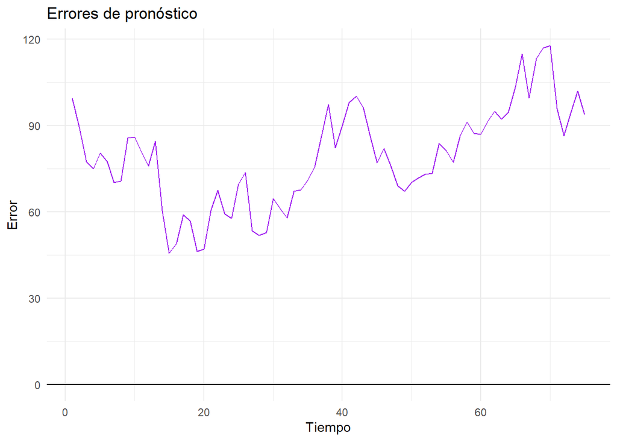

```r
resultado_errores_austres_mm$grafico_errores
```

Los errores nunca bajan de 0, siempre son positivos, y van subiendo con el tiempo: empiezan cerca de 100, bajan un poco hasta 45 y luego suben otra vez hasta casi 120 al final. Esto confirma el sesgo: el modelo se queda atrás de la serie real todo el tiempo, y cada vez se queda más atrás.

**Correlograma**

**Mostrar/ocultar código**

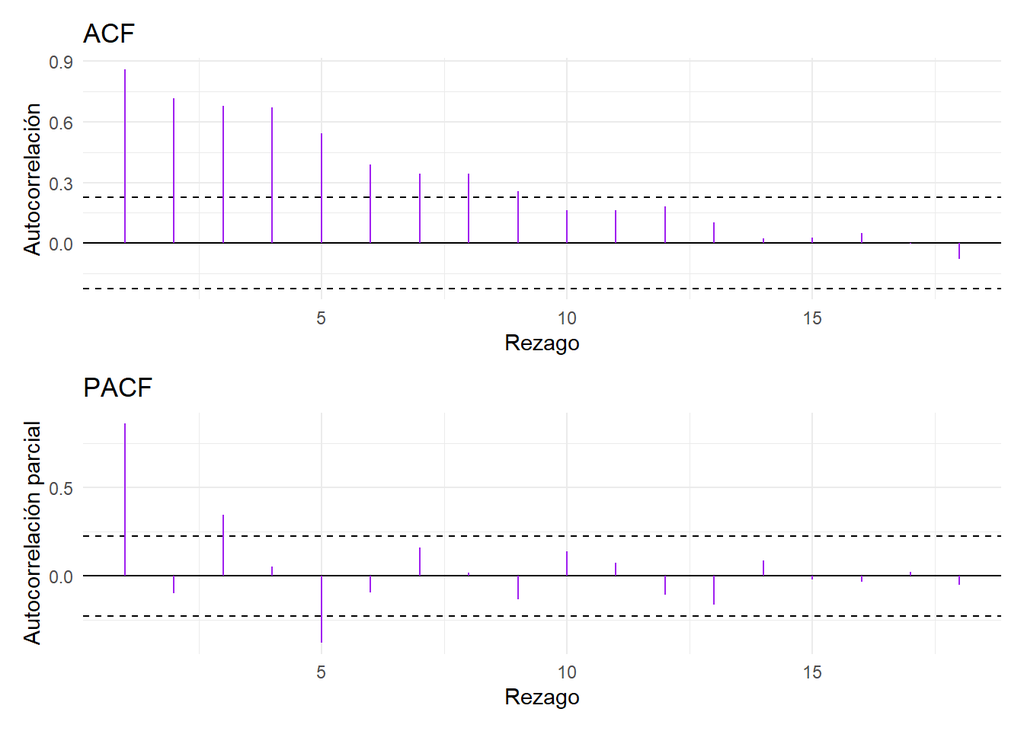

```r
resultado_errores_austres_mm$correlograma$grafico
```

En el ACF, los primeros 9 rezagos salen de la banda, con una caída lenta desde casi 0.9. En el PACF solo los rezagos 1, 3 y 5 se salen de la banda. Esto muestra que los errores dependen mucho de su valor anterior, y que ese vínculo se va arrastrando en los rezagos siguientes.

**Prueba t (errores)**

**Mostrar/ocultar código**

```r
cat(
  "Estadístico de prueba:", round(resultado_errores_austres_mm$t, 4), "\n",
  "Grados de libertad:", resultado_errores_austres_mm$grados_libertad_t, "\n",
  "Valor crítico:", round(
    qt(0.975, resultado_errores_austres_mm$grados_libertad_t), 4
  ), "\n",
  "Valor p:", round(resultado_errores_austres_mm$valor_p_t, 4), "\n"
)
```

```
Estadístico de prueba: 39.6266
 Grados de libertad: 74
 Valor crítico: 1.9925
 Valor p: 0
```

El estadístico da t=39.63, muy por encima del valor crítico 1.9925, así que se rechaza $H_0$ (valor p < 0.0001). Los errores tienen un sesgo fuerte: el modelo se queda corto de forma sistemática, no es un error al azar.

**Ljung Box (errores)**

**Mostrar/ocultar código**

```r
cat(
  "Estadístico de prueba:", round(
    resultado_errores_austres_mm$ljung_box$estadistico, 4
  ), "\n",
  "Grados de libertad:", resultado_errores_austres_mm$ljung_box$grados_libertad, "\n",
  "Valor crítico:", round(
    resultado_errores_austres_mm$ljung_box$valor_critico, 4
  ), "\n",
  "Valor p:", round(
    resultado_errores_austres_mm$ljung_box$valor_p, 4
  ), "\n"
)
```

```
Estadístico de prueba: 245.2249
 Grados de libertad: 17
 Valor crítico: 27.5871
 Valor p: 0
```

Q=245.22 supera por mucho el valor crítico 27.5871, se rechaza H₀ (valor p < 0.0001). Los errores están muy correlacionados entre sí, nada parecido a ruido blanco.

**Jarque Bera**

**Mostrar/ocultar código**

```r
cat(
  "Estadístico de prueba:", round(
    resultado_errores_austres_mm$jarque_bera$estadistico, 4
  ), "\n",
  "Grados de libertad:", resultado_errores_austres_mm$jarque_bera$grados_libertad, "\n",
  "Valor crítico:", round(
    resultado_errores_austres_mm$jarque_bera$valor_critico, 4
  ), "\n",
  "Valor p:", format.pval(
    resultado_errores_austres_mm$jarque_bera$valor_p,
    digits = 4
  ), "\n"
)
```

```
Estadístico de prueba: 0.7814
 Grados de libertad: 2
 Valor crítico: 5.9915
 Valor p: 0.6766
```

JB=0.7814, por debajo del crítico 5.9915, no se rechaza H₀ (valor p=0.6766). Los errores sí parecen normales.

**Durbin Watson**

**Mostrar/ocultar código**

```r
cat(
  "Estadístico de prueba:", round(
    resultado_errores_austres_mm$durbin_watson$estadistico, 4
  ), "\n",
  "Grados de libertad: no aplica\n",
  "Valor crítico: no calculado\n",
  "Valor p: no calculado\n"
)
```

```
Estadístico de prueba: 0.0112
 Grados de libertad: no aplica
 Valor crítico: no calculado
 Valor p: no calculado
```

DW=0.0112, casi pegado a 0. Confirma una autocorrelación positiva enorme entre errores seguidos, coherente con lo que ya mostró Ljung-Box.

**Gráfico Final**

**Mostrar/ocultar código**

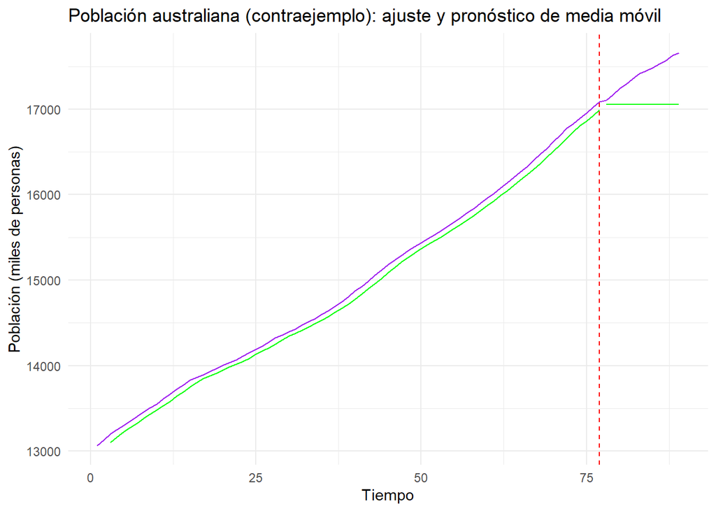

```r
ggplot2::ggplot(
  data.frame(
    tiempo = 1:T_austres,
    real = datos_austres$y,
    ajuste = c(modelo_austres_mm$yhat, rep(NA, h_austres_mm)),
    pronostico = c(rep(NA, T_austres - h_austres_mm), pronosticos_austres_mm)
  ),
  ggplot2::aes(x = tiempo)
) +

  ggplot2::geom_line(
    ggplot2::aes(y = real),
    color = "purple"
  ) +

  ggplot2::geom_line(
    ggplot2::aes(y = ajuste),
    color = "green"
  ) +

  ggplot2::geom_line(
    ggplot2::aes(y = pronostico),
    color = "green"
  ) +

  ggplot2::geom_vline(
    xintercept = T_austres - h_austres_mm,
    color = "red",
    linetype = "dashed"
  ) +

  ggplot2::labs(
    title = "Población australiana (contraejemplo): ajuste y pronóstico de media móvil",
    x = "Tiempo",
    y = "Población (miles de personas)"
  ) +

  ggplot2::theme_minimal()
```

**Conclusión**

Se tomó la serie de Población australiana, ya usada con tendencia lineal, y se le aplicó media móvil para mostrar qué pasa cuando el supuesto del método (nivel estable, sin tendencia) no se cumple. Con tendencia lineal esta serie había dado un MSE de validación de 44430.97 y un MAPE de 1.21%, superando al ingenuo. Con media móvil, el MSE subió a 152910.66 y el MAPE a 2.01%, quedando incluso peor que el ingenuo simple (MASE de 6.65 frente a 6.09).

En conjunto, estas cuatro cifras muestran que la media móvil no puede seguir una serie con tendencia sostenida: el pronóstico queda fijo en 17055.85 mientras los datos reales siguen creciendo, y el error se acumula cada vez más a medida que pasa el tiempo.

**Mostrar/ocultar código**

```r
#codigo para guardar todas garficas de figs
if (!dir.exists("figs")) dir.create("figs")

# Buscar todos los objetos del ambiente que sean gráficos
nombres_objetos <- ls()

es_grafico <- function(nombre) {
  obj <- get(nombre)
  inherits(obj, "ggplot") || inherits(obj, "patchwork")
}

nombres_graficos <- nombres_objetos[sapply(nombres_objetos, es_grafico)]

cat("Gráficos encontrados:", length(nombres_graficos), "\n")
```

```
Gráficos encontrados: 35
```

**Mostrar/ocultar código**

```r
for (nombre in nombres_graficos) {

  grafico <- get(nombre)

  ggplot2::ggsave(
    filename = paste0("figs/", nombre, ".png"),
    plot = grafico,
    width = 8,
    height = 6,
    dpi = 150
  )
}

cat("Gráficos guardados en figs/:", paste(nombres_graficos, collapse = ", "), "\n")
```

```
Gráficos guardados en figs/: grafico_airmiles, grafico_austres, grafico_co2, grafico_disc, grafico_J, grafico_Lake, grafico_lynx, grafico_nottem, grafico_opt_austres_mm, grafico_opt_disc_ses, grafico_opt_nottem, grafico_opt_pet, grafico_opt_W, grafico_pet, grafico_serie, grafico_sun, grafico_UK, gra…
```